# **Machine Learning - LAB7 - Restricted Boltzmann Machines and Deep Belief Networks**

**Field of Study: Computer Science - Data Science**  
**Author: Bartłomiej Jamiołkowski**

```python
from datasets import load_dataset
from sklearn.datasets import fetch_openml
from sklearn.neural_network import BernoulliRBM
from sklearn.linear_model import LogisticRegression
from sklearn.ensemble import RandomForestClassifier
from skimage.metrics import structural_similarity as ssim
from sklearn.model_selection import GridSearchCV
from sklearn.pipeline import Pipeline
from sklearn.utils import gen_batches
from PIL import Image
from tensorflow.keras.models import Model
from tensorflow.keras import layers
from IPython.display import Image
from pathlib import Path

import matplotlib.pyplot as plt
import pandas as pd
import numpy as np
import tensorflow as tf
import joblib
import glob
import re
import math
import warnings
warnings.filterwarnings('ignore')
```

### 1. Feature extraction using Restricted Boltzmann Machine

The experiments in this task must be performed for all datasets mentioned in section 3, with the MNIST and Fashion-MNIST datasets being mandatory.

#### 1.1 Load a dataset. These are grayscale images, assigned to one of many classes, with a pre-defined division into training and test sets (in the case of MNIST and Fashion-MNIST, this is 60,000 training records and 10,000 test records).

**a) MNIST dataset**

```python
mnist_data = load_dataset('ylecun/mnist')
```

**b) Fashion-MNIST dataset**

```python
fashion_mnist_data = load_dataset('zalando-datasets/fashion_mnist')
```

**c) Kuzushiji-MNIST dataset**

```python
X_train_kmnist = np.load('data/kmnist/kmnist-train-imgs.npz')['arr_0']
X_test_kmnist = np.load('data/kmnist/kmnist-test-imgs.npz')['arr_0']
Y_train_kmnist = np.load('data/kmnist/kmnist-train-labels.npz')['arr_0']
Y_test_kmnist = np.load('data/kmnist/kmnist-test-labels.npz')['arr_0']
```

**d) Kuzushiji-49 dataset**

```python
X_train_k49 = np.load('data/k49/k49-train-imgs.npz')['arr_0']
X_test_k49 = np.load('data/k49/k49-test-imgs.npz')['arr_0']
Y_train_k49 = np.load('data/k49/k49-train-labels.npz')['arr_0']
Y_test_k49 = np.load('data/k49/k49-test-labels.npz')['arr_0']
```

#### 1.2 and 1.3 Binarize images (both training and test sets), then display 10 sample records from the training set. Convert data to numpy arrays.

```python
def binarize_images(sample):
    return (np.array(sample['image']) > 127).astype(np.uint8)
```

```python
def display_n_sample_records(X_data: np.array, Y_data: np.array, n: int) -> None:
    image_indices = np.random.choice(range(X_data.shape[0]), n, replace = False)
    images = X_data[image_indices]
    labels = Y_data[image_indices]

    fig, axes = plt.subplots(1, n, figsize = (15, 5))
    for i in range(n):
        axes[i].imshow(images[i], cmap = 'gray')
        axes[i].set_title(f'Label: {labels[i]}')
        axes[i].axis('off')
    plt.show()
```

**a) MNIST dataset**

```python
mnist_data = mnist_data.with_format('np')
```

```python
X_train_mnist = binarize_images(mnist_data['train'])
X_test_mnist = binarize_images(mnist_data['test'])
Y_train_mnist = mnist_data['train']['label']
Y_test_mnist = mnist_data['test']['label']
```

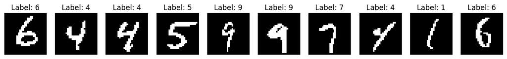

```python
display_n_sample_records(X_train_mnist, Y_train_mnist, 10)
```

**b) Fashion-MNIST dataset**

```python
fashion_mnist_data = fashion_mnist_data.with_format('np')
```

```python
X_train_fashion_mnist = binarize_images(fashion_mnist_data['train'])
X_test_fashion_mnist = binarize_images(fashion_mnist_data['test'])
Y_train_fashion_mnist = fashion_mnist_data['train']['label']
Y_test_fashion_mnist = fashion_mnist_data['test']['label']
```

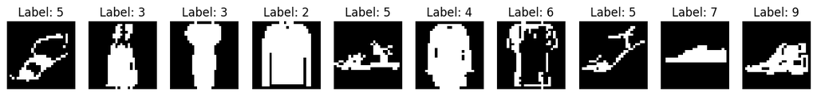

```python
display_n_sample_records(X_train_fashion_mnist, Y_train_fashion_mnist, 10)
```

**c) Kuzushiji-MNIST dataset**

```python
X_train_kmnist = (np.array(X_train_kmnist) > 127).astype(np.uint8)
X_test_kmnist = (np.array(X_test_kmnist) > 127).astype(np.uint8)
```

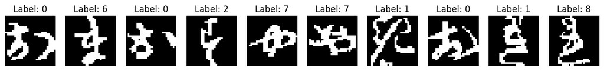

```python
display_n_sample_records(X_train_kmnist, Y_train_kmnist, 10)
```

**d) Kuzushiji-49 dataset**

```python
X_train_k49 = (np.array(X_train_k49) > 127).astype(np.uint8)
X_test_k49 = (np.array(X_test_k49) > 127).astype(np.uint8)
```

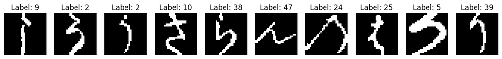

```python
display_n_sample_records(X_train_k49, Y_train_k49, 10)
```

#### 1.4 Build a Pipeline consisting of:

- BernoulliRBM for feature extraction
- LogisticRegression as a classifier

```python
rbm = BernoulliRBM(random_state = 42)
logistic = LogisticRegression(random_state = 42)

pipeline = Pipeline(steps = [('rbm', rbm), ('logistic', logistic)])
```

#### 1.5 and 1.6 Tune model hyperparameters using grid search and cross-validation (GridSearchCV). You can choose the parameter grid according to your dataset and available computational resources. Present and comment on the obtained hyperparameter values, then train the RBM and classifier according to them.

```python
param_grid = {
    'rbm__n_components': [70, 80, 90],
    'rbm__learning_rate': [0.05, 0.1],
    'rbm__batch_size': [10, 20],
    'logistic__C': [0.1, 0.5, 1.0],
}
```

```python
grid_search = GridSearchCV(
    pipeline,
    param_grid,
    cv = 3,
    scoring = 'f1',
    verbose = 2,
    n_jobs = -1
)
```

**a) MNIST dataset**

```python
X_train_mnist_flattened = X_train_mnist.reshape(X_train_mnist.shape[0], -1)
X_test_mnist_flattened = X_test_mnist.reshape(X_test_mnist.shape[0], -1)
```

```python
grid_search.fit(X_train_mnist_flattened, Y_train_mnist)
joblib.dump(grid_search, 'models/grid_search_model_mnist.pkl')
```

```
Fitting 3 folds for each of 36 candidates, totalling 108 fits
```

```
['models/grid_search_model_mnist.pkl']
```

```python
grid_search_model_mnist = joblib.load('models/grid_search_model_mnist.pkl')
print(f'Best parameters: {grid_search_model_mnist.best_params_}')
```

```
Best parameters: {'logistic__C': 0.1, 'rbm__batch_size': 10, 'rbm__learning_rate': 0.05, 'rbm__n_components': 70}
```

```python
best_model_mnist = grid_search_model_mnist.best_estimator_
```

**b) Fashion-MNIST dataset**

```python
X_train_fashion_mnist_flattened = X_train_fashion_mnist.reshape(X_train_fashion_mnist.shape[0], -1)
X_test_fashion_mnist_flattened = X_test_fashion_mnist.reshape(X_test_fashion_mnist.shape[0], -1)
```

```python
grid_search.fit(X_train_fashion_mnist_flattened, Y_train_fashion_mnist)
joblib.dump(grid_search, 'models/grid_search_model_fashion_mnist.pkl')
```

```
Fitting 3 folds for each of 36 candidates, totalling 108 fits
```

```
['models/grid_search_model_fashion_mnist.pkl']
```

```python
grid_search_model_fashion_mnist = joblib.load('models/grid_search_model_fashion_mnist.pkl')
print(f'Best parameters: {grid_search_model_fashion_mnist.best_params_}')
```

```
Best parameters: {'logistic__C': 0.1, 'rbm__batch_size': 10, 'rbm__learning_rate': 0.05, 'rbm__n_components': 70}
```

```python
best_model_fashion_mnist = grid_search_model_fashion_mnist.best_estimator_
```

**c) Kuzushiji-MNIST dataset**

```python
X_train_kmnist_flattened = X_train_kmnist.reshape(X_train_kmnist.shape[0], -1)
X_test_kmnist_flattened = X_test_kmnist.reshape(X_test_kmnist.shape[0], -1)
```

```python
grid_search.fit(X_train_kmnist_flattened, Y_train_kmnist)
joblib.dump(grid_search, 'models/grid_search_model_kmnist.pkl')
```

```
Fitting 3 folds for each of 36 candidates, totalling 108 fits
```

```
['models/grid_search_model_kmnist.pkl']
```

```python
grid_search_model_kmnist = joblib.load('models/grid_search_model_kmnist.pkl')
print(f'Best parameters: {grid_search_model_kmnist.best_params_}')
```

```
Best parameters: {'logistic__C': 0.1, 'rbm__batch_size': 10, 'rbm__learning_rate': 0.05, 'rbm__n_components': 70}
```

```python
best_model_kmnist = grid_search_model_kmnist.best_estimator_
```

**d) Kuzushiji-49 dataset**

```python
X_train_k49_flattened = X_train_k49.reshape(X_train_k49.shape[0], -1)
X_test_k49_flattened = X_test_k49.reshape(X_test_k49.shape[0], -1)
```

```python
grid_search.fit(X_train_k49_flattened, Y_train_k49)
joblib.dump(grid_search, 'models/grid_search_model_k49.pkl')
```

```
Fitting 3 folds for each of 36 candidates, totalling 108 fits
```

```
['models/grid_search_model_k49.pkl']
```

```python
grid_search_model_k49 = joblib.load('models/grid_search_model_k49.pkl')
print(f'Best parameters: {grid_search_model_k49.best_params_}')
```

```
Best parameters: {'logistic__C': 0.1, 'rbm__batch_size': 10, 'rbm__learning_rate': 0.05, 'rbm__n_components': 70}
```

```python
best_model_k49 = grid_search_model_k49.best_estimator_
```

#### 1.7 Perform classification on the test set and present detailed results (accuracy, precision, recall, f1-score):

- At the level of each class
- Aggregate

There is the classification_report() function, which partially returns the expected results. However, it does not completely satisfy the task e.g there is no accuracy for each class, so I am going to implement it from scratch.

```python
def calc_metrics(TP: int, FP: int, FN: int, TN: int) -> tuple:
    accuracy = (TP + TN) / (TP + FP + FN + TN) if (TP + FP + FN + TN) > 0 else 0
    precision = TP / (TP + FP) if (TP + FP) > 0 else 0
    recall = TP / (TP + FN) if (TP + FN) > 0 else 0
    f1_score = 2 * (precision * recall) / (precision + recall) if (precision + recall) > 0 else 0
    return accuracy, precision, recall, f1_score

def show_classification_metrics(Y_test: np.ndarray, Y_pred: np.ndarray) -> None:
    metrics_df = pd.DataFrame(columns = ['accuracy', 'precision', 'recall', 'f1-score'])
    total_TP, total_FP, total_FN, total_TN = 0, 0, 0, 0

    for cls in np.unique(Y_test):
        TP = np.sum((Y_test == cls) & (Y_pred == cls))
        FP = np.sum((Y_test != cls) & (Y_pred == cls))
        FN = np.sum((Y_test == cls) & (Y_pred != cls))
        TN = np.sum((Y_test != cls) & (Y_pred != cls))

        total_TP += TP
        total_FP += FP
        total_FN += FN
        total_TN += TN

        accuracy, precision, recall, f1_score = calc_metrics(TP, FP, FN, TN)

        new_row = pd.DataFrame({'accuracy': [accuracy], 'precision': [precision], 'recall': [recall], 'f1-score': [f1_score]})
        metrics_df = pd.concat([metrics_df, new_row], ignore_index = True)

    total_accuracy, total_precision, total_recall, total_f1_score = calc_metrics(total_TP, total_FP, total_FN, total_TN)
    new_row = pd.DataFrame({'accuracy': [total_accuracy], 'precision': [total_precision], 'recall': [total_recall], 'f1-score': [total_f1_score]},
                          index = ['aggregated'])
    metrics_df = pd.concat([metrics_df, new_row], ignore_index = False)
    display(metrics_df)
```

**a) MNIST dataset**

```python
Y_pred_mnist = best_model_mnist.predict(X_test_mnist_flattened)
```

```python
show_classification_metrics(Y_test_mnist, Y_pred_mnist)
```

|  | accuracy | precision | recall | f1-score |
| --- | --- | --- | --- | --- |
| 0 | 0.99140 | 0.936523 | 0.978571 | 0.957086 |
| 1 | 0.99470 | 0.974561 | 0.978855 | 0.976703 |
| 2 | 0.98160 | 0.921471 | 0.898256 | 0.909715 |
| 3 | 0.97580 | 0.877210 | 0.884158 | 0.880671 |
| 4 | 0.97830 | 0.890705 | 0.887984 | 0.889342 |
| 5 | 0.97610 | 0.887307 | 0.838565 | 0.862248 |
| 6 | 0.98770 | 0.931748 | 0.940501 | 0.936104 |
| 7 | 0.98420 | 0.932406 | 0.912451 | 0.922321 |
| 8 | 0.97750 | 0.877901 | 0.893224 | 0.885496 |
| 9 | 0.97350 | 0.862573 | 0.877106 | 0.869779 |
| aggregated | 0.98208 | 0.910400 | 0.910400 | 0.910400 |

**b) Fashion-MNIST dataset**

```python
Y_pred_fashion_mnist = best_model_fashion_mnist.predict(X_test_fashion_mnist_flattened)
```

```python
show_classification_metrics(Y_test_fashion_mnist, Y_pred_fashion_mnist)
```

|  | accuracy | precision | recall | f1-score |
| --- | --- | --- | --- | --- |
| 0 | 0.94410 | 0.707823 | 0.7510 | 0.728772 |
| 1 | 0.98890 | 0.968388 | 0.9190 | 0.943048 |
| 2 | 0.92220 | 0.625566 | 0.5530 | 0.587049 |
| 3 | 0.95640 | 0.763551 | 0.8170 | 0.789372 |
| 4 | 0.91780 | 0.565828 | 0.7650 | 0.650510 |
| 5 | 0.96670 | 0.824732 | 0.8470 | 0.835718 |
| 6 | 0.89350 | 0.448331 | 0.2820 | 0.346225 |
| 7 | 0.96810 | 0.852850 | 0.8230 | 0.837659 |
| 8 | 0.97780 | 0.874038 | 0.9090 | 0.891176 |
| 9 | 0.97770 | 0.879765 | 0.9000 | 0.889768 |
| aggregated | 0.95132 | 0.756600 | 0.7566 | 0.756600 |

**c) Kuzushiji-MNIST dataset**

```python
Y_pred_kmnist = best_model_kmnist.predict(X_test_kmnist_flattened)
```

```python
show_classification_metrics(Y_test_kmnist, Y_pred_kmnist)
```

|  | accuracy | precision | recall | f1-score |
| --- | --- | --- | --- | --- |
| 0 | 0.96220 | 0.833691 | 0.7770 | 0.804348 |
| 1 | 0.92530 | 0.615525 | 0.6740 | 0.643437 |
| 2 | 0.91120 | 0.551002 | 0.6050 | 0.576740 |
| 3 | 0.95910 | 0.792864 | 0.8000 | 0.796416 |
| 4 | 0.91300 | 0.558348 | 0.6220 | 0.588458 |
| 5 | 0.96110 | 0.854820 | 0.7360 | 0.790973 |
| 6 | 0.93480 | 0.660517 | 0.7160 | 0.687140 |
| 7 | 0.93400 | 0.730352 | 0.5390 | 0.620253 |
| 8 | 0.93990 | 0.683533 | 0.7430 | 0.712027 |
| 9 | 0.94020 | 0.704684 | 0.6920 | 0.698285 |
| aggregated | 0.93808 | 0.690400 | 0.6904 | 0.690400 |

**d) Kuzushiji-49 dataset**

```python
Y_pred_k49 = best_model_k49.predict(X_test_k49_flattened)
```

```python
show_classification_metrics(Y_test_k49, Y_pred_k49)
```

|  | accuracy | precision | recall | f1-score |
| --- | --- | --- | --- | --- |
| 0 | 0.971489 | 0.456388 | 0.518000 | 0.485246 |
| 1 | 0.988430 | 0.773176 | 0.784000 | 0.778550 |
| 2 | 0.983553 | 0.653266 | 0.780000 | 0.711030 |
| 3 | 0.996939 | 0.537037 | 0.460317 | 0.495726 |
| 4 | 0.979298 | 0.599409 | 0.609000 | 0.604167 |
| 5 | 0.973487 | 0.483582 | 0.324000 | 0.388024 |
| 6 | 0.966949 | 0.383305 | 0.450000 | 0.413983 |
| 7 | 0.980154 | 0.608495 | 0.659000 | 0.632741 |
| 8 | 0.973694 | 0.348466 | 0.370274 | 0.359039 |
| 9 | 0.979454 | 0.630000 | 0.504000 | 0.560000 |
| 10 | 0.980439 | 0.635165 | 0.578000 | 0.605236 |
| 11 | 0.978909 | 0.593970 | 0.591000 | 0.592481 |
| 12 | 0.964070 | 0.335047 | 0.391000 | 0.360868 |
| 13 | 0.984020 | 0.548896 | 0.513274 | 0.530488 |
| 14 | 0.983942 | 0.509881 | 0.410175 | 0.454626 |
| 15 | 0.971022 | 0.444444 | 0.468000 | 0.455918 |
| 16 | 0.992139 | 0.617587 | 0.722488 | 0.665932 |
| 17 | 0.974213 | 0.502953 | 0.511000 | 0.506944 |
| 18 | 0.982126 | 0.631668 | 0.746000 | 0.684090 |
| 19 | 0.975796 | 0.533534 | 0.533000 | 0.533267 |
| 20 | 0.968402 | 0.391218 | 0.392000 | 0.391608 |
| 21 | 0.972942 | 0.478478 | 0.478000 | 0.478239 |
| 22 | 0.990946 | 0.480712 | 0.482143 | 0.481426 |
| 23 | 0.987055 | 0.396266 | 0.478697 | 0.433598 |
| 24 | 0.975510 | 0.526465 | 0.557000 | 0.541302 |
| 25 | 0.975510 | 0.545752 | 0.334000 | 0.414392 |
| 26 | 0.984927 | 0.655678 | 0.642344 | 0.648943 |
| 27 | 0.983682 | 0.707727 | 0.632000 | 0.667723 |
| 28 | 0.989831 | 0.854312 | 0.733000 | 0.789020 |
| 29 | 0.991517 | 0.491803 | 0.277778 | 0.355030 |
| 30 | 0.969829 | 0.430520 | 0.505000 | 0.464795 |
| 31 | 0.986199 | 0.448171 | 0.295181 | 0.355932 |
| 32 | 0.994007 | 0.571848 | 0.696429 | 0.628019 |
| 33 | 0.985680 | 0.500000 | 0.413043 | 0.452381 |
| 34 | 0.970815 | 0.448644 | 0.546000 | 0.492558 |
| 35 | 0.975822 | 0.538636 | 0.474000 | 0.504255 |
| 36 | 0.993099 | 0.488550 | 0.492308 | 0.490421 |
| 37 | 0.983734 | 0.655029 | 0.788000 | 0.715388 |
| 38 | 0.973046 | 0.483088 | 0.557000 | 0.517418 |
| 39 | 0.968143 | 0.380753 | 0.364000 | 0.372188 |
| 40 | 0.971386 | 0.436341 | 0.353000 | 0.390271 |
| 41 | 0.968376 | 0.409728 | 0.497000 | 0.449164 |
| 42 | 0.991128 | 0.510490 | 0.419540 | 0.460568 |
| 43 | 0.989960 | 0.505576 | 0.348718 | 0.412747 |
| 44 | 0.998236 | 0.500000 | 0.220588 | 0.306122 |
| 45 | 0.998002 | 0.377358 | 0.312500 | 0.341880 |
| 46 | 0.974732 | 0.512621 | 0.528000 | 0.520197 |
| 47 | 0.988196 | 0.724280 | 0.880000 | 0.794582 |
| 48 | 0.985394 | 0.511677 | 0.419861 | 0.461244 |
| aggregated | 0.980943 | 0.533115 | 0.533115 | 0.533115 |

#### 1.8 Does nonlinear feature extraction using RBM improve classification results compared to baseline (logistic regression on raw pixels)?

**a) MNIST dataset**

```python
best_model_mnist['logistic'].fit(X_train_mnist_flattened, Y_train_mnist)
Y_pred_mnist_baseline = best_model_mnist['logistic'].predict(X_test_mnist_flattened)
show_classification_metrics(Y_test_mnist, Y_pred_mnist_baseline)
```

|  | accuracy | precision | recall | f1-score |
| --- | --- | --- | --- | --- |
| 0 | 0.99220 | 0.947421 | 0.974490 | 0.960765 |
| 1 | 0.99230 | 0.955250 | 0.977974 | 0.966478 |
| 2 | 0.98130 | 0.930683 | 0.884690 | 0.907104 |
| 3 | 0.98060 | 0.899217 | 0.909901 | 0.904528 |
| 4 | 0.98410 | 0.919470 | 0.918534 | 0.919002 |
| 5 | 0.97720 | 0.885151 | 0.855381 | 0.870011 |
| 6 | 0.98830 | 0.933059 | 0.945720 | 0.939347 |
| 7 | 0.98350 | 0.923454 | 0.915370 | 0.919394 |
| 8 | 0.97510 | 0.868020 | 0.877823 | 0.872894 |
| 9 | 0.98000 | 0.900892 | 0.900892 | 0.900892 |
| aggregated | 0.98346 | 0.917300 | 0.917300 | 0.917300 |

**b) Fashion-MNIST dataset**

```python
best_model_fashion_mnist['logistic'].fit(X_train_fashion_mnist_flattened, Y_train_fashion_mnist)
Y_pred_fashion_mnist_baseline = best_model_fashion_mnist['logistic'].predict(X_test_fashion_mnist_flattened)
show_classification_metrics(Y_test_fashion_mnist, Y_pred_fashion_mnist_baseline)
```

|  | accuracy | precision | recall | f1-score |
| --- | --- | --- | --- | --- |
| 0 | 0.95120 | 0.749513 | 0.7690 | 0.759131 |
| 1 | 0.99000 | 0.955466 | 0.9440 | 0.949698 |
| 2 | 0.93730 | 0.693264 | 0.6690 | 0.680916 |
| 3 | 0.95950 | 0.797203 | 0.7980 | 0.797601 |
| 4 | 0.93920 | 0.690661 | 0.7100 | 0.700197 |
| 5 | 0.97240 | 0.843454 | 0.8890 | 0.865628 |
| 6 | 0.90750 | 0.540107 | 0.5050 | 0.521964 |
| 7 | 0.97500 | 0.866928 | 0.8860 | 0.876360 |
| 8 | 0.98000 | 0.905680 | 0.8930 | 0.899295 |
| 9 | 0.98370 | 0.920603 | 0.9160 | 0.918296 |
| aggregated | 0.95958 | 0.797900 | 0.7979 | 0.797900 |

**c) Kuzushiji-MNIST dataset**

```python
best_model_kmnist['logistic'].fit(X_train_kmnist_flattened, Y_train_kmnist)
Y_pred_kmnist_baseline = best_model_kmnist['logistic'].predict(X_test_kmnist_flattened)
show_classification_metrics(Y_test_kmnist, Y_pred_kmnist_baseline)
```

|  | accuracy | precision | recall | f1-score |
| --- | --- | --- | --- | --- |
| 0 | 0.96440 | 0.855408 | 0.7750 | 0.813221 |
| 1 | 0.92820 | 0.633270 | 0.6700 | 0.651118 |
| 2 | 0.90330 | 0.513317 | 0.6360 | 0.568111 |
| 3 | 0.95840 | 0.804167 | 0.7720 | 0.787755 |
| 4 | 0.92960 | 0.651020 | 0.6380 | 0.644444 |
| 5 | 0.94590 | 0.744931 | 0.6980 | 0.720702 |
| 6 | 0.93780 | 0.676966 | 0.7230 | 0.699226 |
| 7 | 0.93870 | 0.755614 | 0.5720 | 0.651110 |
| 8 | 0.93150 | 0.634271 | 0.7440 | 0.684768 |
| 9 | 0.93600 | 0.695228 | 0.6410 | 0.667014 |
| aggregated | 0.93738 | 0.686900 | 0.6869 | 0.686900 |

**d) Kuzushiji-49 dataset**

```python
best_model_k49['logistic'].fit(X_train_k49_flattened, Y_train_k49)
Y_pred_k49_baseline = best_model_k49['logistic'].predict(X_test_k49_flattened)
show_classification_metrics(Y_test_k49, Y_pred_k49_baseline)
```

|  | accuracy | precision | recall | f1-score |
| --- | --- | --- | --- | --- |
| 0 | 0.977430 | 0.569593 | 0.532000 | 0.550155 |
| 1 | 0.988663 | 0.775171 | 0.793000 | 0.783984 |
| 2 | 0.982982 | 0.628358 | 0.842000 | 0.719658 |
| 3 | 0.996939 | 0.533333 | 0.507937 | 0.520325 |
| 4 | 0.983786 | 0.705818 | 0.643000 | 0.672946 |
| 5 | 0.972268 | 0.457355 | 0.370000 | 0.409066 |
| 6 | 0.974602 | 0.511182 | 0.480000 | 0.495101 |
| 7 | 0.978623 | 0.573211 | 0.689000 | 0.625795 |
| 8 | 0.975718 | 0.386577 | 0.375489 | 0.380952 |
| 9 | 0.979039 | 0.609091 | 0.536000 | 0.570213 |
| 10 | 0.983371 | 0.714970 | 0.597000 | 0.650681 |
| 11 | 0.977508 | 0.556886 | 0.651000 | 0.600277 |
| 12 | 0.965964 | 0.357664 | 0.392000 | 0.374046 |
| 13 | 0.986017 | 0.625225 | 0.511799 | 0.562855 |
| 14 | 0.985784 | 0.580517 | 0.464229 | 0.515901 |
| 15 | 0.970426 | 0.434334 | 0.463000 | 0.448209 |
| 16 | 0.993878 | 0.704955 | 0.748804 | 0.726218 |
| 17 | 0.979350 | 0.604294 | 0.591000 | 0.597573 |
| 18 | 0.983008 | 0.640816 | 0.785000 | 0.705618 |
| 19 | 0.976496 | 0.543278 | 0.590000 | 0.565676 |
| 20 | 0.972060 | 0.461072 | 0.456000 | 0.458522 |
| 21 | 0.975018 | 0.517806 | 0.538000 | 0.527710 |
| 22 | 0.992580 | 0.580645 | 0.535714 | 0.557276 |
| 23 | 0.989234 | 0.476190 | 0.401003 | 0.435374 |
| 24 | 0.978390 | 0.580676 | 0.601000 | 0.590663 |
| 25 | 0.975069 | 0.527046 | 0.380000 | 0.441604 |
| 26 | 0.987625 | 0.735256 | 0.671053 | 0.701689 |
| 27 | 0.983527 | 0.710496 | 0.616000 | 0.659882 |
| 28 | 0.990038 | 0.845291 | 0.754000 | 0.797040 |
| 29 | 0.991621 | 0.502183 | 0.354938 | 0.415913 |
| 30 | 0.973279 | 0.485795 | 0.513000 | 0.499027 |
| 31 | 0.986769 | 0.484615 | 0.379518 | 0.425676 |
| 32 | 0.994630 | 0.621262 | 0.667857 | 0.643718 |
| 33 | 0.988352 | 0.615730 | 0.496377 | 0.549649 |
| 34 | 0.972086 | 0.469841 | 0.592000 | 0.523894 |
| 35 | 0.976522 | 0.561930 | 0.431000 | 0.487832 |
| 36 | 0.993099 | 0.485577 | 0.388462 | 0.431624 |
| 37 | 0.986251 | 0.693257 | 0.843000 | 0.760830 |
| 38 | 0.969803 | 0.439528 | 0.596000 | 0.505942 |
| 39 | 0.968117 | 0.395814 | 0.435000 | 0.414483 |
| 40 | 0.972138 | 0.458520 | 0.409000 | 0.432347 |
| 41 | 0.970581 | 0.442341 | 0.514000 | 0.475486 |
| 42 | 0.991569 | 0.533141 | 0.531609 | 0.532374 |
| 43 | 0.989805 | 0.494340 | 0.335897 | 0.400000 |
| 44 | 0.998469 | 0.609756 | 0.367647 | 0.458716 |
| 45 | 0.998599 | 0.638889 | 0.359375 | 0.460000 |
| 46 | 0.976652 | 0.550710 | 0.543000 | 0.546828 |
| 47 | 0.987184 | 0.712963 | 0.847000 | 0.774223 |
| 48 | 0.984720 | 0.484725 | 0.414634 | 0.446948 |
| aggregated | 0.982156 | 0.562819 | 0.562819 | 0.562819 |

The obtained results indicate that the impact of nonlinear feature extraction using RBM depends on the dataset and set hyperparameters. For the MNIST, Fashion-MNIST and Kuzushiji-49 datasets, the classification results deteriorated when RBM was applied for feature extraction. In contrast, for the Kuzushiji-MNIST dataset, the results improved, suggesting that RBM is more effective in certain cases. This variability highlights the importance of considering the nature of the dataset when applying techniques like RBM for feature extraction.

#### 1.9 Visualize all extracted hidden features (n components of images corresponding to learned weights associated with a specific hidden layer element). Try to recognize which high-level image features are enhanced by a specific component.

```python
def visualize_extracted_hidden_features(sklearn_pipeline: Pipeline) -> None:
    n_components, n_vector = sklearn_pipeline['rbm'].components_.shape
    image_height, image_width = int(np.sqrt(n_vector)), int(np.sqrt(n_vector))

    plt.figure(figsize = (8, 8))
    for i, comp in enumerate(sklearn_pipeline['rbm'].components_):
        plt.subplot(n_components // 10, 10, i + 1)
        plt.imshow(comp.reshape(image_height, image_width), cmap = plt.cm.gray_r, interpolation = 'nearest')
        plt.xticks(())
        plt.yticks(())

    plt.suptitle(f'{n_components} components extracted by RBM', fontsize = 16, y = 0.9)
    plt.subplots_adjust(hspace = 0.3, wspace = 0.1)
    plt.show()
```

**a) MNIST dataset**

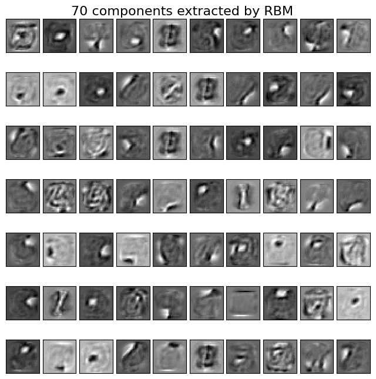

```python
visualize_extracted_hidden_features(best_model_mnist)
```

The presented visualization indicates that most of the components enhance shapes and edges of the digits shown in the images. For example, I can clearly identify numbers such as: 2, 4 and 5 in the learned features.

**b) Fashion-MNIST dataset**

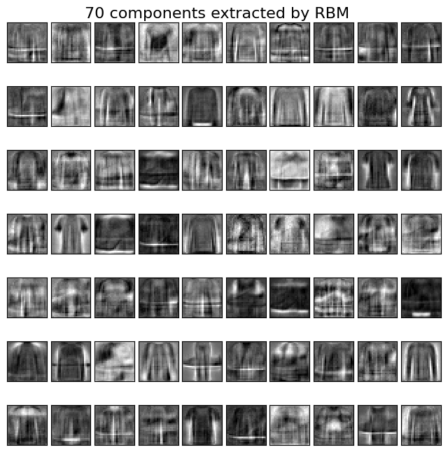

```python
visualize_extracted_hidden_features(best_model_fashion_mnist)
```

The presented visualization indicates that components enhance: shapes, edges and patterns of the clothes shown in the images. For example, I can clearly identify e.g. trousers or skirts.

**c) Kuzushiji-MNIST dataset**

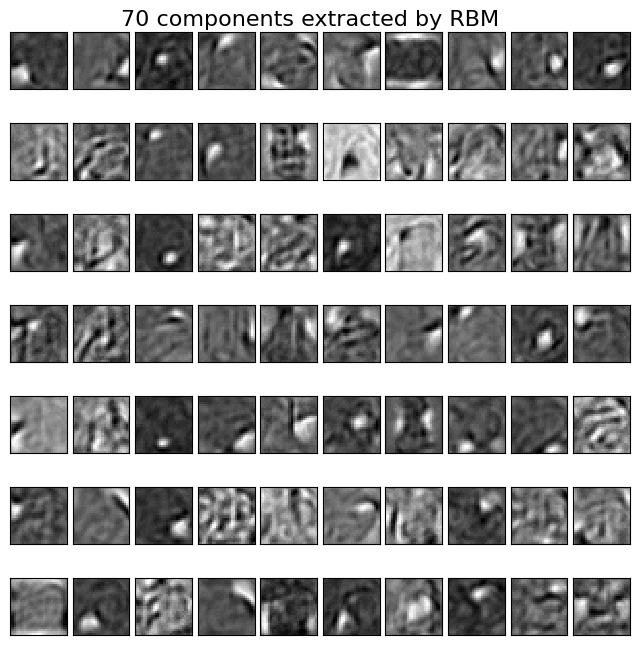

```python
visualize_extracted_hidden_features(best_model_kmnist)
```

The presented visualization indicates that most of the components enhance shapes and edges of the digits shown in the images.

**d) Kuzushiji-49 dataset**

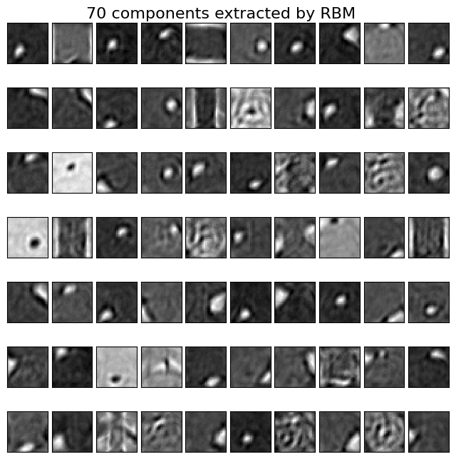

```python
visualize_extracted_hidden_features(best_model_k49)
```

The presented visualization indicates that most of the components enhance shapes and edges of the digits shown in the images.

### 2. Hierarchical Feature Extraction Using Deep Belief Network

In this section, we will check whether stacking multiple RBMs, i.e. building a Deep Belief Network model (and hierarchical feature extraction), will improve the previously obtained classification results. As in the previous task, the experiments should be performed for all datasets listed in point 3, with the MNIST and Fashion-MNIST datasets being mandatory.

#### 2.1 and 2.2 Configure 3 RBMs so that the hidden layer of RBM(i) becomes the input layer (visible layer) of BRM(i + 1). The RBMs are trained in sequential order: 1, 2, 3. The hidden layer size is predefined, for example for MNIST we suggest: 256, 128, 64. For other data sets you can adjust these sizes empirically, but grid search is not required (high computational requirements). The values of the remaining hyperparameters can be similar to those in the previous task.

```python
def classify_with_dbn(X_train: np.ndarray, Y_train: np.ndarray, X_test: np.ndarray, components_list: list) -> np.ndarray:
    rbms = []
    hidden_features_train = X_train
    hidden_features_test = X_test

    for i in range(len(components_list)):
        rbm = BernoulliRBM(n_components = components_list[i], batch_size = 10, learning_rate = 0.05, random_state = 42)
        hidden_features_train = rbm.fit_transform(hidden_features_train)
        rbms.append(rbm)

    logistic = LogisticRegression(C = 0.1, random_state = 42)
    logistic.fit(hidden_features_train, Y_train)

    for rbm in rbms:
        hidden_features_test = rbm.transform(hidden_features_test)

    return logistic.predict(hidden_features_test)
```

#### 2.3 Compare classification results obtained using logistic regression, for the following feature extraction variants:

- Baseline - logistic regression on raw pixels
- Full hierarchical extraction (all 3 RBMs)
- First RBM
- First and second RBM

Baseline - logistic regression was computed in previous task, so below code refers to feature extraction variants based on RBM.

**a) MNIST dataset**

```python
Y_pred_mnist_3_rbms = classify_with_dbn(X_train_mnist_flattened, Y_train_mnist, X_test_mnist_flattened, [256, 128, 64])
joblib.dump(Y_pred_mnist_3_rbms, 'results/Y_pred_mnist_3_rbms.pkl')
```

```
['results/Y_pred_mnist_3_rbms.pkl']
```

```python
Y_pred_mnist_3_rbms = joblib.load('results/Y_pred_mnist_3_rbms.pkl')
show_classification_metrics(Y_test_mnist, Y_pred_mnist_3_rbms)
```

|  | accuracy | precision | recall | f1-score |
| --- | --- | --- | --- | --- |
| 0 | 0.9949 | 0.960357 | 0.988776 | 0.974359 |
| 1 | 0.9960 | 0.980685 | 0.984141 | 0.982410 |
| 2 | 0.9892 | 0.950292 | 0.944767 | 0.947522 |
| 3 | 0.9840 | 0.927565 | 0.912871 | 0.920160 |
| 4 | 0.9894 | 0.947853 | 0.943992 | 0.945918 |
| 5 | 0.9864 | 0.926637 | 0.920404 | 0.923510 |
| 6 | 0.9942 | 0.967775 | 0.971816 | 0.969792 |
| 7 | 0.9881 | 0.958628 | 0.924125 | 0.941060 |
| 8 | 0.9833 | 0.898322 | 0.934292 | 0.915954 |
| 9 | 0.9825 | 0.916168 | 0.909812 | 0.912979 |
| aggregated | 0.9888 | 0.944000 | 0.944000 | 0.944000 |

```python
Y_pred_mnist_2_rbms = classify_with_dbn(X_train_mnist_flattened, Y_train_mnist, X_test_mnist_flattened, [128, 64])
joblib.dump(Y_pred_mnist_2_rbms, 'results/Y_pred_mnist_2_rbms.pkl')
```

```
['results/Y_pred_mnist_2_rbms.pkl']
```

```python
Y_pred_mnist_2_rbms = joblib.load('results/Y_pred_mnist_2_rbms.pkl')
show_classification_metrics(Y_test_mnist, Y_pred_mnist_2_rbms)
```

|  | accuracy | precision | recall | f1-score |
| --- | --- | --- | --- | --- |
| 0 | 0.99350 | 0.959799 | 0.974490 | 0.967089 |
| 1 | 0.99490 | 0.974606 | 0.980617 | 0.977602 |
| 2 | 0.98810 | 0.943635 | 0.940891 | 0.942261 |
| 3 | 0.98270 | 0.909892 | 0.919802 | 0.914820 |
| 4 | 0.98320 | 0.913618 | 0.915479 | 0.914547 |
| 5 | 0.98390 | 0.910213 | 0.909193 | 0.909703 |
| 6 | 0.99210 | 0.954498 | 0.963466 | 0.958961 |
| 7 | 0.98520 | 0.951745 | 0.901751 | 0.926074 |
| 8 | 0.98040 | 0.902692 | 0.895277 | 0.898969 |
| 9 | 0.97660 | 0.875849 | 0.894945 | 0.885294 |
| aggregated | 0.98606 | 0.930300 | 0.930300 | 0.930300 |

```python
Y_pred_mnist_1_rbm = classify_with_dbn(X_train_mnist_flattened, Y_train_mnist, X_test_mnist_flattened, [64])
joblib.dump(Y_pred_mnist_1_rbm, 'results/Y_pred_mnist_1_rbm.pkl')
```

```
['results/Y_pred_mnist_1_rbm.pkl']
```

```python
Y_pred_mnist_1_rbm = joblib.load('results/Y_pred_mnist_1_rbm.pkl')
show_classification_metrics(Y_test_mnist, Y_pred_mnist_1_rbm)
```

|  | accuracy | precision | recall | f1-score |
| --- | --- | --- | --- | --- |
| 0 | 0.99180 | 0.946322 | 0.971429 | 0.958711 |
| 1 | 0.99460 | 0.972878 | 0.979736 | 0.976295 |
| 2 | 0.98160 | 0.923154 | 0.896318 | 0.909538 |
| 3 | 0.97850 | 0.890855 | 0.897030 | 0.893932 |
| 4 | 0.98120 | 0.916143 | 0.890020 | 0.902893 |
| 5 | 0.97820 | 0.889145 | 0.863229 | 0.875995 |
| 6 | 0.98800 | 0.930185 | 0.945720 | 0.937888 |
| 7 | 0.98390 | 0.935678 | 0.905642 | 0.920415 |
| 8 | 0.97720 | 0.871514 | 0.898357 | 0.884732 |
| 9 | 0.97580 | 0.869105 | 0.894945 | 0.881836 |
| aggregated | 0.98308 | 0.915400 | 0.915400 | 0.915400 |

**b) Fashion-MNIST dataset**

```python
Y_pred_fashion_mnist_3_rbms = classify_with_dbn(X_train_fashion_mnist_flattened, Y_train_fashion_mnist, X_test_fashion_mnist_flattened, [256, 128, 64])
joblib.dump(Y_pred_fashion_mnist_3_rbms, 'results/Y_pred_fashion_mnist_3_rbms.pkl')
```

```
['results/Y_pred_fashion_mnist_3_rbms.pkl']
```

```python
Y_pred_fashion_mnist_3_rbms = joblib.load('results/Y_pred_fashion_mnist_3_rbms.pkl')
show_classification_metrics(Y_test_fashion_mnist, Y_pred_fashion_mnist_3_rbms)
```

|  | accuracy | precision | recall | f1-score |
| --- | --- | --- | --- | --- |
| 0 | 0.93590 | 0.660125 | 0.7400 | 0.697784 |
| 1 | 0.99130 | 0.981033 | 0.9310 | 0.955362 |
| 2 | 0.90400 | 0.519417 | 0.5350 | 0.527094 |
| 3 | 0.95750 | 0.791287 | 0.7810 | 0.786110 |
| 4 | 0.90470 | 0.524659 | 0.5000 | 0.512033 |
| 5 | 0.96360 | 0.792818 | 0.8610 | 0.825503 |
| 6 | 0.88540 | 0.423319 | 0.4030 | 0.412910 |
| 7 | 0.96420 | 0.863122 | 0.7630 | 0.809979 |
| 8 | 0.97940 | 0.898594 | 0.8950 | 0.896794 |
| 9 | 0.97760 | 0.872361 | 0.9090 | 0.890304 |
| aggregated | 0.94636 | 0.731800 | 0.7318 | 0.731800 |

```python
Y_pred_fashion_mnist_2_rbms = classify_with_dbn(X_train_fashion_mnist_flattened, Y_train_fashion_mnist, X_test_fashion_mnist_flattened, [128, 64])
joblib.dump(Y_pred_fashion_mnist_2_rbms, 'results/Y_pred_fashion_mnist_2_rbms.pkl')
```

```
['results/Y_pred_fashion_mnist_2_rbms.pkl']
```

```python
Y_pred_fashion_mnist_2_rbms = joblib.load('results/Y_pred_fashion_mnist_2_rbms.pkl')
show_classification_metrics(Y_test_fashion_mnist, Y_pred_fashion_mnist_2_rbms)
```

|  | accuracy | precision | recall | f1-score |
| --- | --- | --- | --- | --- |
| 0 | 0.9407 | 0.687213 | 0.7470 | 0.715860 |
| 1 | 0.9884 | 0.964286 | 0.9180 | 0.940574 |
| 2 | 0.9224 | 0.617400 | 0.5890 | 0.602866 |
| 3 | 0.9537 | 0.758920 | 0.7870 | 0.772705 |
| 4 | 0.9293 | 0.629075 | 0.7140 | 0.668852 |
| 5 | 0.9602 | 0.769713 | 0.8590 | 0.811909 |
| 6 | 0.8891 | 0.436406 | 0.3740 | 0.402800 |
| 7 | 0.9613 | 0.856810 | 0.7360 | 0.791824 |
| 8 | 0.9804 | 0.904427 | 0.8990 | 0.901705 |
| 9 | 0.9755 | 0.874133 | 0.8820 | 0.878049 |
| aggregated | 0.9501 | 0.750500 | 0.7505 | 0.750500 |

```python
Y_pred_fashion_mnist_1_rbm = classify_with_dbn(X_train_fashion_mnist_flattened, Y_train_fashion_mnist, X_test_fashion_mnist_flattened, [64])
joblib.dump(Y_pred_fashion_mnist_1_rbm, 'results/Y_pred_fashion_mnist_1_rbm.pkl')
```

```
['results/Y_pred_fashion_mnist_1_rbm.pkl']
```

```python
Y_pred_fashion_mnist_1_rbm = joblib.load('results/Y_pred_fashion_mnist_1_rbm.pkl')
show_classification_metrics(Y_test_fashion_mnist, Y_pred_fashion_mnist_1_rbm)
```

|  | accuracy | precision | recall | f1-score |
| --- | --- | --- | --- | --- |
| 0 | 0.94140 | 0.699807 | 0.7250 | 0.712181 |
| 1 | 0.98900 | 0.964509 | 0.9240 | 0.943820 |
| 2 | 0.92330 | 0.633448 | 0.5530 | 0.590497 |
| 3 | 0.95750 | 0.781036 | 0.7990 | 0.789916 |
| 4 | 0.92010 | 0.577130 | 0.7520 | 0.653061 |
| 5 | 0.96780 | 0.825962 | 0.8590 | 0.842157 |
| 6 | 0.88930 | 0.428951 | 0.3230 | 0.368511 |
| 7 | 0.96850 | 0.853457 | 0.8270 | 0.840020 |
| 8 | 0.97830 | 0.877531 | 0.9100 | 0.893471 |
| 9 | 0.97840 | 0.888889 | 0.8960 | 0.892430 |
| aggregated | 0.95136 | 0.756800 | 0.7568 | 0.756800 |

**c) Kuzushiji-MNIST dataset**

```python
Y_pred_kmnist_3_rbms = classify_with_dbn(X_train_kmnist_flattened, Y_train_kmnist, X_test_kmnist_flattened, [256, 128, 64])
joblib.dump(Y_pred_kmnist_3_rbms, 'results/Y_pred_kmnist_3_rbms.pkl')
```

```
['results/Y_pred_kmnist_3_rbms.pkl']
```

```python
Y_pred_kmnist_3_rbms = joblib.load('results/Y_pred_kmnist_3_rbms.pkl')
show_classification_metrics(Y_test_kmnist, Y_pred_kmnist_3_rbms)
```

|  | accuracy | precision | recall | f1-score |
| --- | --- | --- | --- | --- |
| 0 | 0.96770 | 0.875694 | 0.7890 | 0.830089 |
| 1 | 0.95480 | 0.761950 | 0.7970 | 0.779081 |
| 2 | 0.93920 | 0.684211 | 0.7280 | 0.705426 |
| 3 | 0.96620 | 0.808769 | 0.8670 | 0.836873 |
| 4 | 0.94690 | 0.729677 | 0.7450 | 0.737259 |
| 5 | 0.96640 | 0.886946 | 0.7610 | 0.819160 |
| 6 | 0.94510 | 0.688703 | 0.8230 | 0.749886 |
| 7 | 0.95720 | 0.819196 | 0.7340 | 0.774262 |
| 8 | 0.95310 | 0.755043 | 0.7860 | 0.770211 |
| 9 | 0.96560 | 0.862031 | 0.7810 | 0.819517 |
| aggregated | 0.95622 | 0.781100 | 0.7811 | 0.781100 |

```python
Y_pred_kmnist_2_rbms = classify_with_dbn(X_train_kmnist_flattened, Y_train_kmnist, X_test_kmnist_flattened, [128, 64])
joblib.dump(Y_pred_kmnist_2_rbms, 'results/Y_pred_kmnist_2_rbms.pkl')
```

```
['results/Y_pred_kmnist_2_rbms.pkl']
```

```python
Y_pred_kmnist_2_rbms = joblib.load('results/Y_pred_kmnist_2_rbms.pkl')
show_classification_metrics(Y_test_kmnist, Y_pred_kmnist_2_rbms)
```

|  | accuracy | precision | recall | f1-score |
| --- | --- | --- | --- | --- |
| 0 | 0.96100 | 0.841928 | 0.7510 | 0.793869 |
| 1 | 0.93140 | 0.633731 | 0.7440 | 0.684453 |
| 2 | 0.92290 | 0.598963 | 0.6930 | 0.642559 |
| 3 | 0.95870 | 0.793794 | 0.7930 | 0.793397 |
| 4 | 0.93120 | 0.642077 | 0.7050 | 0.672069 |
| 5 | 0.96300 | 0.871462 | 0.7390 | 0.799784 |
| 6 | 0.94240 | 0.697026 | 0.7500 | 0.722543 |
| 7 | 0.95110 | 0.825478 | 0.6480 | 0.726050 |
| 8 | 0.94970 | 0.723270 | 0.8050 | 0.761950 |
| 9 | 0.95680 | 0.831002 | 0.7130 | 0.767492 |
| aggregated | 0.94682 | 0.734100 | 0.7341 | 0.734100 |

```python
Y_pred_kmnist_1_rbm = classify_with_dbn(X_train_kmnist_flattened, Y_train_kmnist, X_test_kmnist_flattened, [64])
joblib.dump(Y_pred_kmnist_1_rbm, 'results/Y_pred_kmnist_1_rbm.pkl')
```

```
['results/Y_pred_kmnist_1_rbm.pkl']
```

```python
Y_pred_kmnist_1_rbm = joblib.load('results/Y_pred_kmnist_1_rbm.pkl')
show_classification_metrics(Y_test_kmnist, Y_pred_kmnist_1_rbm)
```

|  | accuracy | precision | recall | f1-score |
| --- | --- | --- | --- | --- |
| 0 | 0.95980 | 0.845266 | 0.7320 | 0.784566 |
| 1 | 0.92100 | 0.593085 | 0.6690 | 0.628759 |
| 2 | 0.90690 | 0.530612 | 0.5980 | 0.562294 |
| 3 | 0.95570 | 0.773845 | 0.7870 | 0.780367 |
| 4 | 0.92230 | 0.605090 | 0.6420 | 0.622999 |
| 5 | 0.95300 | 0.808858 | 0.6940 | 0.747040 |
| 6 | 0.92970 | 0.632708 | 0.7080 | 0.668240 |
| 7 | 0.93210 | 0.711462 | 0.5400 | 0.613985 |
| 8 | 0.93250 | 0.645479 | 0.7210 | 0.681153 |
| 9 | 0.93860 | 0.703586 | 0.6670 | 0.684805 |
| aggregated | 0.93516 | 0.675800 | 0.6758 | 0.675800 |

**d) Kuzushiji-49 dataset**

```python
Y_pred_k49_3_rbms = classify_with_dbn(X_train_k49_flattened, Y_train_k49, X_test_k49_flattened, [256, 128, 64])
joblib.dump(Y_pred_k49_3_rbms, 'results/Y_pred_k49_3_rbms.pkl')
```

```
['results/Y_pred_k49_3_rbms.pkl']
```

```python
Y_pred_k49_3_rbms = joblib.load('results/Y_pred_k49_3_rbms.pkl')
show_classification_metrics(Y_test_k49, Y_pred_k49_3_rbms)
```

|  | accuracy | precision | recall | f1-score |
| --- | --- | --- | --- | --- |
| 0 | 0.969622 | 0.441075 | 0.640000 | 0.522236 |
| 1 | 0.990349 | 0.839093 | 0.777000 | 0.806854 |
| 2 | 0.985991 | 0.706463 | 0.787000 | 0.744560 |
| 3 | 0.995720 | 0.361702 | 0.404762 | 0.382022 |
| 4 | 0.979350 | 0.613333 | 0.552000 | 0.581053 |
| 5 | 0.975407 | 0.540248 | 0.349000 | 0.424058 |
| 6 | 0.971515 | 0.454206 | 0.486000 | 0.469565 |
| 7 | 0.982956 | 0.661640 | 0.702000 | 0.681223 |
| 8 | 0.973746 | 0.370917 | 0.458931 | 0.410256 |
| 9 | 0.979557 | 0.628641 | 0.518000 | 0.567982 |
| 10 | 0.982385 | 0.712021 | 0.539000 | 0.613546 |
| 11 | 0.981944 | 0.675520 | 0.585000 | 0.627010 |
| 12 | 0.965808 | 0.363402 | 0.423000 | 0.390943 |
| 13 | 0.985628 | 0.594801 | 0.573746 | 0.584084 |
| 14 | 0.983267 | 0.484615 | 0.400636 | 0.438642 |
| 15 | 0.972994 | 0.476355 | 0.413000 | 0.442421 |
| 16 | 0.993929 | 0.708145 | 0.748804 | 0.727907 |
| 17 | 0.977716 | 0.581503 | 0.503000 | 0.539410 |
| 18 | 0.985887 | 0.715501 | 0.757000 | 0.735666 |
| 19 | 0.975433 | 0.525604 | 0.544000 | 0.534644 |
| 20 | 0.968895 | 0.414592 | 0.483000 | 0.446189 |
| 21 | 0.972890 | 0.479377 | 0.523000 | 0.500239 |
| 22 | 0.990220 | 0.441926 | 0.464286 | 0.452830 |
| 23 | 0.980258 | 0.209003 | 0.325815 | 0.254652 |
| 24 | 0.973305 | 0.485514 | 0.486000 | 0.485757 |
| 25 | 0.979609 | 0.662121 | 0.437000 | 0.526506 |
| 26 | 0.986484 | 0.704280 | 0.649522 | 0.675793 |
| 27 | 0.985239 | 0.768369 | 0.617000 | 0.684415 |
| 28 | 0.992762 | 0.951189 | 0.760000 | 0.844914 |
| 29 | 0.991595 | 0.500000 | 0.274691 | 0.354582 |
| 30 | 0.961761 | 0.354064 | 0.575000 | 0.438262 |
| 31 | 0.987159 | 0.504644 | 0.327309 | 0.397077 |
| 32 | 0.994630 | 0.618893 | 0.678571 | 0.647359 |
| 33 | 0.985265 | 0.477901 | 0.313406 | 0.378556 |
| 34 | 0.972709 | 0.478003 | 0.565000 | 0.517874 |
| 35 | 0.977326 | 0.576642 | 0.474000 | 0.520307 |
| 36 | 0.989597 | 0.312000 | 0.450000 | 0.368504 |
| 37 | 0.982956 | 0.640229 | 0.783000 | 0.704453 |
| 38 | 0.976341 | 0.536484 | 0.647000 | 0.586582 |
| 39 | 0.973046 | 0.478595 | 0.436000 | 0.456306 |
| 40 | 0.972812 | 0.468504 | 0.357000 | 0.405221 |
| 41 | 0.971074 | 0.458243 | 0.631000 | 0.530921 |
| 42 | 0.990194 | 0.447552 | 0.367816 | 0.403785 |
| 43 | 0.989779 | 0.492537 | 0.338462 | 0.401216 |
| 44 | 0.998236 | 0.000000 | 0.000000 | 0.000000 |
| 45 | 0.996757 | 0.157303 | 0.218750 | 0.183007 |
| 46 | 0.975925 | 0.531579 | 0.606000 | 0.566355 |
| 47 | 0.991932 | 0.807315 | 0.905000 | 0.853371 |
| 48 | 0.986458 | 0.562500 | 0.407666 | 0.472727 |
| aggregated | 0.981723 | 0.552209 | 0.552209 | 0.552209 |

```python
Y_pred_k49_2_rbms = classify_with_dbn(X_train_k49_flattened, Y_train_k49, X_test_k49_flattened, [128, 64])
joblib.dump(Y_pred_k49_2_rbms, 'results/Y_pred_k49_2_rbms.pkl')
```

```
['results/Y_pred_k49_2_rbms.pkl']
```

```python
Y_pred_k49_2_rbms = joblib.load('results/Y_pred_k49_2_rbms.pkl')
show_classification_metrics(Y_test_k49, Y_pred_k49_2_rbms)
```

|  | accuracy | precision | recall | f1-score |
| --- | --- | --- | --- | --- |
| 0 | 0.974084 | 0.500490 | 0.511000 | 0.505690 |
| 1 | 0.987963 | 0.762745 | 0.778000 | 0.770297 |
| 2 | 0.982048 | 0.622611 | 0.782000 | 0.693262 |
| 3 | 0.996809 | 0.515789 | 0.388889 | 0.443439 |
| 4 | 0.980569 | 0.629248 | 0.611000 | 0.619990 |
| 5 | 0.970659 | 0.412316 | 0.308000 | 0.352604 |
| 6 | 0.968610 | 0.407244 | 0.461000 | 0.432458 |
| 7 | 0.979765 | 0.595321 | 0.687000 | 0.637883 |
| 8 | 0.970659 | 0.307203 | 0.378096 | 0.338983 |
| 9 | 0.976963 | 0.561538 | 0.511000 | 0.535079 |
| 10 | 0.980958 | 0.658333 | 0.553000 | 0.601087 |
| 11 | 0.983137 | 0.707346 | 0.597000 | 0.647505 |
| 12 | 0.966405 | 0.358852 | 0.375000 | 0.366748 |
| 13 | 0.984045 | 0.549921 | 0.511799 | 0.530176 |
| 14 | 0.983942 | 0.510204 | 0.397456 | 0.446828 |
| 15 | 0.967209 | 0.382562 | 0.430000 | 0.404896 |
| 16 | 0.992191 | 0.618661 | 0.729665 | 0.669594 |
| 17 | 0.974421 | 0.507642 | 0.465000 | 0.485386 |
| 18 | 0.983060 | 0.644946 | 0.772000 | 0.702777 |
| 19 | 0.974810 | 0.513718 | 0.543000 | 0.527953 |
| 20 | 0.966586 | 0.374346 | 0.429000 | 0.399814 |
| 21 | 0.972890 | 0.477296 | 0.473000 | 0.475138 |
| 22 | 0.991673 | 0.523659 | 0.494048 | 0.508423 |
| 23 | 0.985887 | 0.321867 | 0.328321 | 0.325062 |
| 24 | 0.974551 | 0.508954 | 0.540000 | 0.524017 |
| 25 | 0.977456 | 0.612737 | 0.356000 | 0.450348 |
| 26 | 0.986276 | 0.690211 | 0.666268 | 0.678028 |
| 27 | 0.982671 | 0.686517 | 0.611000 | 0.646561 |
| 28 | 0.989727 | 0.842404 | 0.743000 | 0.789586 |
| 29 | 0.991335 | 0.476190 | 0.308642 | 0.374532 |
| 30 | 0.970659 | 0.444160 | 0.521000 | 0.479521 |
| 31 | 0.984798 | 0.391089 | 0.317269 | 0.350333 |
| 32 | 0.994319 | 0.594427 | 0.685714 | 0.636816 |
| 33 | 0.985602 | 0.496815 | 0.423913 | 0.457478 |
| 34 | 0.973513 | 0.490428 | 0.538000 | 0.513114 |
| 35 | 0.977300 | 0.585034 | 0.430000 | 0.495677 |
| 36 | 0.992840 | 0.464602 | 0.403846 | 0.432099 |
| 37 | 0.982800 | 0.638912 | 0.775000 | 0.700407 |
| 38 | 0.970478 | 0.449265 | 0.611000 | 0.517797 |
| 39 | 0.964718 | 0.318548 | 0.316000 | 0.317269 |
| 40 | 0.968195 | 0.375276 | 0.340000 | 0.356768 |
| 41 | 0.969647 | 0.429285 | 0.516000 | 0.468665 |
| 42 | 0.990583 | 0.476636 | 0.439655 | 0.457399 |
| 43 | 0.990401 | 0.538760 | 0.356410 | 0.429012 |
| 44 | 0.998495 | 0.727273 | 0.235294 | 0.355556 |
| 45 | 0.997951 | 0.346939 | 0.265625 | 0.300885 |
| 46 | 0.977249 | 0.563077 | 0.549000 | 0.555949 |
| 47 | 0.988352 | 0.733673 | 0.865000 | 0.793942 |
| 48 | 0.984331 | 0.467532 | 0.376307 | 0.416988 |
| aggregated | 0.980808 | 0.529795 | 0.529795 | 0.529795 |

```python
Y_pred_k49_1_rbm = classify_with_dbn(X_train_k49_flattened, Y_train_k49, X_test_k49_flattened, [64])
joblib.dump(Y_pred_k49_1_rbm, 'results/Y_pred_k49_1_rbm.pkl')
```

```
['results/Y_pred_k49_1_rbm.pkl']
```

```python
Y_pred_k49_1_rbm = joblib.load('results/Y_pred_k49_1_rbm.pkl')
show_classification_metrics(Y_test_k49, Y_pred_k49_1_rbm)
```

|  | accuracy | precision | recall | f1-score |
| --- | --- | --- | --- | --- |
| 0 | 0.970270 | 0.437713 | 0.513000 | 0.472376 |
| 1 | 0.987470 | 0.762437 | 0.751000 | 0.756675 |
| 2 | 0.983604 | 0.649593 | 0.799000 | 0.716592 |
| 3 | 0.996835 | 0.517857 | 0.460317 | 0.487395 |
| 4 | 0.980102 | 0.612343 | 0.635000 | 0.623466 |
| 5 | 0.971152 | 0.414373 | 0.271000 | 0.327690 |
| 6 | 0.967313 | 0.398119 | 0.508000 | 0.446397 |
| 7 | 0.980128 | 0.606947 | 0.664000 | 0.634193 |
| 8 | 0.975225 | 0.377285 | 0.376793 | 0.377038 |
| 9 | 0.978234 | 0.598773 | 0.488000 | 0.537741 |
| 10 | 0.978649 | 0.594249 | 0.558000 | 0.575554 |
| 11 | 0.979480 | 0.607179 | 0.592000 | 0.599494 |
| 12 | 0.967261 | 0.356044 | 0.324000 | 0.339267 |
| 13 | 0.984798 | 0.574194 | 0.525074 | 0.548536 |
| 14 | 0.983604 | 0.497207 | 0.424483 | 0.457976 |
| 15 | 0.971723 | 0.453416 | 0.438000 | 0.445575 |
| 16 | 0.992788 | 0.656250 | 0.703349 | 0.678984 |
| 17 | 0.974473 | 0.508753 | 0.465000 | 0.485893 |
| 18 | 0.980932 | 0.610879 | 0.730000 | 0.665148 |
| 19 | 0.974732 | 0.512897 | 0.517000 | 0.514940 |
| 20 | 0.967780 | 0.389194 | 0.425000 | 0.406310 |
| 21 | 0.973357 | 0.485149 | 0.441000 | 0.462022 |
| 22 | 0.991621 | 0.520000 | 0.502976 | 0.511346 |
| 23 | 0.985135 | 0.311688 | 0.360902 | 0.334495 |
| 24 | 0.973253 | 0.486344 | 0.552000 | 0.517096 |
| 25 | 0.977274 | 0.608014 | 0.349000 | 0.443456 |
| 26 | 0.985031 | 0.661673 | 0.633971 | 0.647526 |
| 27 | 0.982878 | 0.687638 | 0.623000 | 0.653725 |
| 28 | 0.989727 | 0.837054 | 0.750000 | 0.791139 |
| 29 | 0.991465 | 0.485714 | 0.262346 | 0.340681 |
| 30 | 0.968688 | 0.414250 | 0.500000 | 0.453104 |
| 31 | 0.985680 | 0.419162 | 0.281124 | 0.336538 |
| 32 | 0.993488 | 0.542029 | 0.667857 | 0.598400 |
| 33 | 0.986017 | 0.513627 | 0.443841 | 0.476190 |
| 34 | 0.971412 | 0.456186 | 0.531000 | 0.490758 |
| 35 | 0.976470 | 0.553633 | 0.480000 | 0.514194 |
| 36 | 0.992114 | 0.417293 | 0.426923 | 0.422053 |
| 37 | 0.983890 | 0.658843 | 0.786000 | 0.716826 |
| 38 | 0.972086 | 0.467128 | 0.540000 | 0.500928 |
| 39 | 0.966223 | 0.360701 | 0.391000 | 0.375240 |
| 40 | 0.968714 | 0.381062 | 0.330000 | 0.353698 |
| 41 | 0.966846 | 0.390723 | 0.497000 | 0.437500 |
| 42 | 0.990842 | 0.492447 | 0.468391 | 0.480118 |
| 43 | 0.989416 | 0.464844 | 0.305128 | 0.368421 |
| 44 | 0.998366 | 0.600000 | 0.220588 | 0.322581 |
| 45 | 0.998054 | 0.396226 | 0.328125 | 0.358974 |
| 46 | 0.974525 | 0.508303 | 0.551000 | 0.528791 |
| 47 | 0.988196 | 0.731128 | 0.862000 | 0.791189 |
| 48 | 0.985420 | 0.513043 | 0.411150 | 0.456480 |
| aggregated | 0.980668 | 0.526370 | 0.526370 | 0.526370 |

#### 2.4 Is setting RBM extractors beneficial for each dataset? When can hierarchical feature extraction be useful?

The effectiveness of setting RBM extractors depends on the dataset and its inherent structure. The results show that RBM extractors were not universally beneficial across all datasets. For MNIST and Kuzushiji-MNIST, the application of RBM extractors proved to be advantageous, enhancing the classification results compared to the baseline in most cases. However, there was an exception with the first RBM, which did not always provide an improvement.

In contrast, for Fashion-MNIST and Kuzushiji-49, using RBM extractors resulted in worse accuracy than the baseline. This decline was particularly evident in Fashion-MNIST, where each additional RBM led to progressively worse results. This suggests that RBM extractors were unable to capture meaningful features for these datasets or caused the model to overfit the training data.

Summarizing, hierarchical feature extraction may not always be beneficial. For datasets without clear hierarchical structures or those with very complex features (like Fashion-MNIST), the extracted features may not generalize well, leading to degraded performance.

Hierarchical feature extraction, as implemented through stacked RBMs, can be useful in specific scenarios. It is particularly effective when working with datasets that have complex, layered structures, such as:

- visual datasets with hierarchical features e.g. MNIST,
- datasets with significant noise - RBMs may help filter out irrelevant features, retaining only the most important aspects of the data,
- dimensionality reduction tasks - RBMs can compactly represent high-dimensional data while preserving the key information needed for classification.

### 3. Restricted Boltzmann Machines: Implementation, Reconstruction Tests

#### 3.1 Implement RBM with the Contrastive Divergence training algorithm.

```python
class RBM():
    def __init__(self, visible_dim, hidden_dim):
        self.visible_dim = visible_dim
        self.hidden_dim = hidden_dim
        self.weights = np.random.randn(visible_dim, hidden_dim)
        self.biases_hidden = np.random.randn(hidden_dim)
        self.biases_visible = np.random.randn(visible_dim)

    def fit(self, X, epochs = 10, batch_dim = 50, lr = 0.1):
        for epoch in range(epochs):
            self.plot_weights(step = epoch, save = True)
            error_epoch = 0
            batches = list(gen_batches(X.shape[0], batch_dim))

            for batch in batches:
                batch = X[batch.start:batch.stop]
                batch_size = batch.shape[0]

                ones_poshidP = np.ones((batch_size, self.hidden_dim))
                poshidP = ones_poshidP/(ones_poshidP + np.exp(-np.dot(batch,self.weights) - self.biases_hidden))
                wake = np.dot(batch.T, poshidP)

                ones_reconDataP = np.ones((batch_size, self.visible_dim))
                reconDataP = ones_reconDataP / (ones_reconDataP + np.exp(-np.dot(poshidP, np.transpose(self.weights)) - self.biases_visible))
                ones_neghidP = np.ones((batch_size, self.hidden_dim))
                neghidP = ones_neghidP / (ones_neghidP + np.exp(-np.dot(reconDataP, self.weights) - self.biases_hidden))
                dream = np.dot(np.transpose(reconDataP), neghidP)
                error = np.sum((batch-reconDataP) ** 2)/batch_size

                self.weights += lr * (wake - dream) / batch_size
                self.biases_hidden += lr * (np.sum(poshidP - neghidP, axis = 0)) / batch_size
                self.biases_visible += lr * (np.sum(batch - reconDataP, axis = 0)) / batch_size

                error_epoch += error

            error_epoch /= len(batches)
            print(f"epoch: {epoch}/{epochs} \t{'error:'} {error_epoch}")

    def reconstruct(self, X):
        ones_poshidP = np.ones((X.shape[0], self.hidden_dim))
        poshidP = ones_poshidP / (ones_poshidP + np.exp(-np.dot(X,self.weights) - self.biases_hidden))
        poshidS = poshidP > np.random.uniform(size = poshidP.shape)

        ones_reconDataP = np.ones((X.shape[0], self.visible_dim))
        reconDataP = ones_reconDataP / (ones_reconDataP + np.exp(-np.dot(poshidS,np.transpose(self.weights)) - self.biases_visible))

        return reconDataP

    def plot_weights(self, title = 'weights', step = 0, save = True):
        cols = 5
        rows = int(self.hidden_dim / cols)

        plt.clf()
        fig, axes = plt.subplots(rows, cols, figsize = (10, 10))
        fig.suptitle(f'{title} step:{step}')
        for i in range(rows):
            for j in range(cols):
                axes[i, j].imshow(self.weights[:, i * cols + j].reshape(28, 28), cmap = 'gray')
                axes[i, j].axis('off')

        plt.subplots_adjust(wspace = 1, hspace = 1)

        if save:
            plt.savefig(f'{title}_step_{step}.png')
        else:
            plt.show()

        plt.close()
```

#### 3.2 Train RBM on the Fashion-MNIST dataset (training part) for a hidden layer (hidden dim) of size 40. Use default values for fit() method parameters.

```python
plt.ioff()
rbm = RBM(visible_dim = X_train_fashion_mnist_flattened.shape[1], hidden_dim = 40)
rbm.fit(X_train_fashion_mnist_flattened)
plt.ion()
```

```
epoch: 0/10 	error: 95.91394711247844
epoch: 1/10 	error: 84.09786895964257
epoch: 2/10 	error: 81.50758895743907
epoch: 3/10 	error: 79.82484950123147
epoch: 4/10 	error: 79.42446780975212
epoch: 5/10 	error: 80.35226150704568
epoch: 6/10 	error: 80.56055421756933
epoch: 7/10 	error: 80.65788450197057
epoch: 8/10 	error: 80.64334588744941
epoch: 9/10 	error: 80.46294949997856
```

```
<contextlib.ExitStack at 0x2681f7939d0>
```

At the start of training, the reconstruction error is high at 95.91 in epoch 0, reflecting the model's lack of learned features. Over the first four epochs, the error steadily decreases, reaching 79.42 by epoch 4, showing effective learning during initial training. After epoch 4, the error plateaus and fluctuates slightly, with values like 80.35 in epoch 5 and 80.65 in epoch 7. This suggests the model has stopped improving, possibly due to overfitting or instability in the training process.

#### 3.3 Visualize how the weights change over the training epochs. In this cell, call the plot weights() method in the fit() method. Present the results as an animated GIF file. Record observations regarding training progress.

```python
file_pattern = re.compile(r'.*?(\d+).*?')

def get_order(file):
    match = file_pattern.match(Path(file).name)
    if not match:
        return math.inf
    return int(match.groups()[0])


frames = [Image.open(image) for image in sorted(glob.glob(f'./weights_step_*.png'), key = get_order)]
frame_one = frames[0]
frame_one.save('weights.gif', format = 'GIF', append_images = frames, save_all = True, duration = 1000, loop = 0)
```

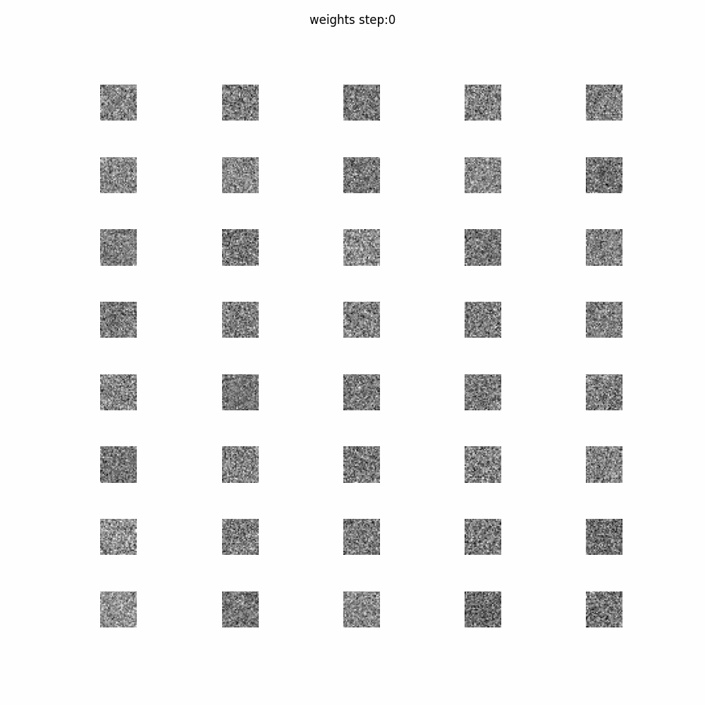

```python
from IPython.display import Image
Image(open('weights.gif','rb').read())
```

In the generated GIF, it is noticeable that as the epochs progress, the weights start to form recognizable patterns, often resembling specific clothes. This suggests that the RBM is capturing essential features of the clothes from the Fashion-MNIST dataset. When weights start to align with recognizable patterns, it means that the RBM’s hidden units are effectively encoding parts of the input data. Each unit is learning to detect particular features that are useful for reconstructing clothes.

#### 3.4 Select 10 examples from the test set (one for each class). Then, use RBM to reconstruct the test image. Compare the resulting reconstruction with the original image:

- Present visualization: original image vs. image reconstructed based on learned RBM weights (for each class),
- Quantitatively: apply Structural Similarity Index (SSIM).

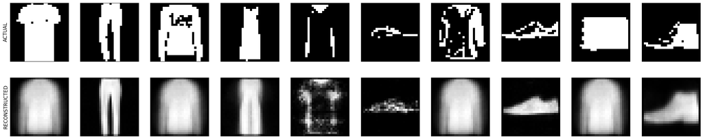

```python
digit_indices = [np.where(Y_test_fashion_mnist == i)[0][0] for i in range(10)]
resticted_set = X_test_fashion_mnist_flattened[digit_indices]
reconstructed = rbm.reconstruct(resticted_set)

fig, axes = plt.subplots(2, 10, sharey = True, figsize = (30, 6))
for i in range(2):
    for j in range(10):
        if i==0:
          axes[i, j].imshow(resticted_set[j].reshape(28, 28), cmap = 'gray')
        else:
          axes[i, j].imshow(reconstructed[j].reshape(28, 28), cmap = 'gray')

        axes[i, j].tick_params(left = False, right = False , labelleft = False, labelbottom = False, bottom = False)

axes[0, 0].set_ylabel('ACTUAL', fontsize = 12)
axes[1, 0].set_ylabel('RECONSTRUCTED', fontsize = 12)
plt.show()
```

```python
reconstructed = rbm.reconstruct(X_test_fashion_mnist_flattened)
X_test1 = X_test_fashion_mnist_flattened.astype(float)
ssim_score = 0

for i in range(len(X_test1)):
  ssim_score += ssim(X_test1[i], reconstructed[i], data_range = X_test1[i].max() - X_test1[i].min())

ssim_score /= len(X_test_fashion_mnist_flattened)
print(f'SSIM score: {ssim_score}')
```

```
SSIM score: 0.34166528898435905
```

The SSIM score of about 0.3417 for the Fashion-MNIST dataset suggests a low level of similarity between the original and reconstructed images. Given that Fashion-MNIST consists of grayscale images of clothing items with subtle and complex details, this score highlights limitations in the current feature extraction or reconstruction process. It is probably caused by hyperparameters values and the fact that RBMs prioritize learning features over accurate reconstruction.

### 4. Feature extraction using Autoencoder

In this task, we want to check whether image feature extraction using different types of Autoencoders can improve previously obtained classification results. We will consider both simple Autoencoders and deep models composed of DBNs. The task is open-ended - you can propose your own architectures (using 4 e.g. variational AE architectures from the previous lab). As in the previous task, the experiments should be performed for all data sets listed in point 3, with the MNIST and Fashion-MNIST sets being mandatory.

#### 4.1 Load the dataset. Scale the features to [0, 1] and convert them to numpy arrays (both training and test data).

```python
def normalize_images(images):
    images = images.reshape((images.shape[0], 28, 28, 1)) / 255.
    return images.astype('float32')
```

**a) MNIST dataset**

```python
mnist_data = load_dataset('ylecun/mnist')
mnist_data = mnist_data.with_format('np')
```

```python
X_train_mnist = normalize_images(mnist_data['train']['image'])
X_test_mnist = normalize_images(mnist_data['test']['image'])
Y_train_mnist = mnist_data['train']['label']
Y_test_mnist = mnist_data['test']['label']
```

**b) Fashion-MNIST dataset**

```python
fashion_mnist_data = load_dataset('zalando-datasets/fashion_mnist')
fashion_mnist_data = fashion_mnist_data.with_format('np')
```

```python
X_train_fashion_mnist = normalize_images(fashion_mnist_data['train']['image'])
X_test_fashion_mnist = normalize_images(fashion_mnist_data['test']['image'])
Y_train_fashion_mnist = fashion_mnist_data['train']['label']
Y_test_fashion_mnist = fashion_mnist_data['test']['label']
```

**c) Kuzushiji-MNIST dataset**

```python
X_train_kmnist = np.load('data/kmnist/kmnist-train-imgs.npz')['arr_0']
X_test_kmnist = np.load('data/kmnist/kmnist-test-imgs.npz')['arr_0']
Y_train_kmnist = np.load('data/kmnist/kmnist-train-labels.npz')['arr_0']
Y_test_kmnist = np.load('data/kmnist/kmnist-test-labels.npz')['arr_0']
```

```python
X_train_kmnist = normalize_images(X_train_kmnist)
X_test_kmnist = normalize_images(X_test_kmnist)
```

**d) Kuzushiji-49 dataset**

```python
X_train_k49 = np.load('data/k49/k49-train-imgs.npz')['arr_0']
X_test_k49 = np.load('data/k49/k49-test-imgs.npz')['arr_0']
Y_train_k49 = np.load('data/k49/k49-train-labels.npz')['arr_0']
Y_test_k49 = np.load('data/k49/k49-test-labels.npz')['arr_0']
```

```python
X_train_k49 = normalize_images(X_train_k49)
X_test_k49 = normalize_images(X_test_k49)
```

#### 4.2 Build and train a simple Autoencoder. Example configuration of a simple Autoencoder:

- Encoding: ReLU activation
- Decoding: sigmoid activation
- Adam optimizer
- Loss function: binary crossentropy
- Encoding dimension: 196 (number of extracted features)
- Number of training epochs: > 30

```python
class Autoencoder(Model):
    def __init__(self, latent_dim):
        super(Autoencoder, self).__init__()
        self.latent_dim = latent_dim
        self.encoder = tf.keras.Sequential([
            layers.Flatten(),
            layers.Dense(latent_dim, activation = 'relu'),
        ])
        self.decoder = tf.keras.Sequential([
            layers.Dense(784, activation = 'sigmoid'),
            layers.Reshape((28, 28, 1))
        ])

    def call(self, x):
        encoded = self.encoder(x)
        decoded = self.decoder(encoded)
        return decoded
```

```python
latent_dim = 196
autoencoder = Autoencoder(latent_dim)
```

```python
autoencoder.compile(optimizer = 'adam', loss = 'binary_crossentropy')
```

#### 4.3 and 4.4 Show your training progress by displaying loss function values on the training and test sets for subsequent epochs. Using trained Autoencoders generate new features for the training and test sets.

```python
def visualize_new_features(X_original: np.ndarray, X_decoded: np.ndarray) -> None:
    plt.figure(figsize = (20, 4))
    for i in range(10):
        ax = plt.subplot(2, 10, i + 1)
        plt.imshow(X_original[i])
        plt.title('original')
        plt.gray()
        ax.get_xaxis().set_visible(False)
        ax.get_yaxis().set_visible(False)

        ax = plt.subplot(2, 10, i + 1 + 10)
        plt.imshow(X_decoded[i])
        plt.title('reconstructed')
        plt.gray()
        ax.get_xaxis().set_visible(False)
        ax.get_yaxis().set_visible(False)
    plt.show()
```

**a) MNIST dataset**

```python
autoencoder.fit(X_train_mnist, X_train_mnist, epochs = 35, shuffle = True, validation_data = (X_test_mnist, X_test_mnist))
```

```
1875/1875 ━━━━━━━━━━━━━━━━━━━━ 4s 2ms/step - loss: 0.1571 - val_loss: 0.0737
1875/1875 ━━━━━━━━━━━━━━━━━━━━ 3s 2ms/step - loss: 0.0724 - val_loss: 0.0684
1875/1875 ━━━━━━━━━━━━━━━━━━━━ 3s 2ms/step - loss: 0.0684 - val_loss: 0.0667
1875/1875 ━━━━━━━━━━━━━━━━━━━━ 3s 2ms/step - loss: 0.0670 - val_loss: 0.0662
1875/1875 ━━━━━━━━━━━━━━━━━━━━ 3s 2ms/step - loss: 0.0662 - val_loss: 0.0656
1875/1875 ━━━━━━━━━━━━━━━━━━━━ 4s 2ms/step - loss: 0.0659 - val_loss: 0.0653
1875/1875 ━━━━━━━━━━━━━━━━━━━━ 4s 2ms/step - loss: 0.0655 - val_loss: 0.0654
1875/1875 ━━━━━━━━━━━━━━━━━━━━ 4s 2ms/step - loss: 0.0654 - val_loss: 0.0651
1875/1875 ━━━━━━━━━━━━━━━━━━━━ 3s 2ms/step - loss: 0.0653 - val_loss: 0.0650
1875/1875 ━━━━━━━━━━━━━━━━━━━━ 4s 2ms/step - loss: 0.0651 - val_loss: 0.0649
1875/1875 ━━━━━━━━━━━━━━━━━━━━ 4s 2ms/step - loss: 0.0651 - val_loss: 0.0648
1875/1875 ━━━━━━━━━━━━━━━━━━━━ 4s 2ms/step - loss: 0.0650 - val_loss: 0.0648
1875/1875 ━━━━━━━━━━━━━━━━━━━━ 4s 2ms/step - loss: 0.0649 - val_loss: 0.0647
1875/1875 ━━━━━━━━━━━━━━━━━━━━ 4s 2ms/step - loss: 0.0648 - val_loss: 0.0648
1875/1875 ━━━━━━━━━━━━━━━━━━━━ 4s 2ms/step - loss: 0.0648 - val_loss: 0.0647
1875/1875 ━━━━━━━━━━━━━━━━━━━━ 4s 2ms/step - loss: 0.0647 - val_loss: 0.0647
1875/1875 ━━━━━━━━━━━━━━━━━━━━ 4s 2ms/step - loss: 0.0648 - val_loss: 0.0647
1875/1875 ━━━━━━━━━━━━━━━━━━━━ 4s 2ms/step - loss: 0.0647 - val_loss: 0.0646
1875/1875 ━━━━━━━━━━━━━━━━━━━━ 4s 2ms/step - loss: 0.0646 - val_loss: 0.0646
1875/1875 ━━━━━━━━━━━━━━━━━━━━ 4s 2ms/step - loss: 0.0647 - val_loss: 0.0646
1875/1875 ━━━━━━━━━━━━━━━━━━━━ 4s 2ms/step - loss: 0.0646 - val_loss: 0.0646
1875/1875 ━━━━━━━━━━━━━━━━━━━━ 4s 2ms/step - loss: 0.0646 - val_loss: 0.0646
1875/1875 ━━━━━━━━━━━━━━━━━━━━ 4s 2ms/step - loss: 0.0646 - val_loss: 0.0645
1875/1875 ━━━━━━━━━━━━━━━━━━━━ 4s 2ms/step - loss: 0.0646 - val_loss: 0.0645
1875/1875 ━━━━━━━━━━━━━━━━━━━━ 4s 2ms/step - loss: 0.0646 - val_loss: 0.0646
1875/1875 ━━━━━━━━━━━━━━━━━━━━ 4s 2ms/step - loss: 0.0646 - val_loss: 0.0645
1875/1875 ━━━━━━━━━━━━━━━━━━━━ 4s 2ms/step - loss: 0.0646 - val_loss: 0.0645
1875/1875 ━━━━━━━━━━━━━━━━━━━━ 4s 2ms/step - loss: 0.0646 - val_loss: 0.0646
1875/1875 ━━━━━━━━━━━━━━━━━━━━ 4s 2ms/step - loss: 0.0644 - val_loss: 0.0645
1875/1875 ━━━━━━━━━━━━━━━━━━━━ 4s 2ms/step - loss: 0.0644 - val_loss: 0.0645
1875/1875 ━━━━━━━━━━━━━━━━━━━━ 4s 2ms/step - loss: 0.0645 - val_loss: 0.0645
1875/1875 ━━━━━━━━━━━━━━━━━━━━ 4s 2ms/step - loss: 0.0646 - val_loss: 0.0645
1875/1875 ━━━━━━━━━━━━━━━━━━━━ 4s 2ms/step - loss: 0.0645 - val_loss: 0.0646
1875/1875 ━━━━━━━━━━━━━━━━━━━━ 4s 2ms/step - loss: 0.0645 - val_loss: 0.0645
1875/1875 ━━━━━━━━━━━━━━━━━━━━ 4s 2ms/step - loss: 0.0644 - val_loss: 0.0644
```

```
<keras.src.callbacks.history.History at 0x1ee3513ea00>
```

```python
X_train_mnist_encoded = autoencoder.encoder(X_train_mnist).numpy()
X_train_mnist_decoded = autoencoder.decoder(X_train_mnist_encoded).numpy()
```

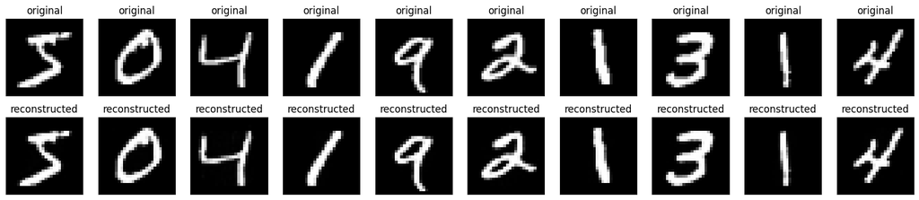

```python
visualize_new_features(X_train_mnist, X_train_mnist_decoded)
```

```python
X_test_mnist_encoded = autoencoder.encoder(X_test_mnist).numpy()
X_test_mnist_decoded = autoencoder.decoder(X_test_mnist_encoded).numpy()
```

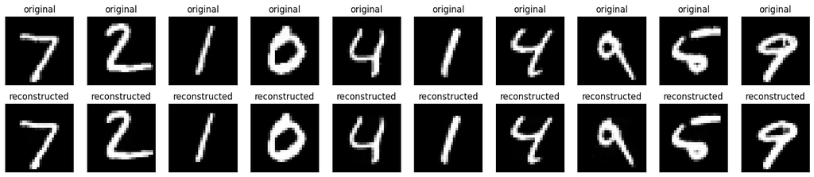

```python
visualize_new_features(X_test_mnist, X_test_mnist_decoded)
```

**b) Fashion-MNIST dataset**

```python
autoencoder.fit(X_train_fashion_mnist, X_train_fashion_mnist, epochs = 35, shuffle = True, validation_data = (X_test_fashion_mnist,
                                                                                                              X_test_fashion_mnist))
```

```
1875/1875 ━━━━━━━━━━━━━━━━━━━━ 3s 2ms/step - loss: 0.3352 - val_loss: 0.2744
1875/1875 ━━━━━━━━━━━━━━━━━━━━ 3s 2ms/step - loss: 0.2699 - val_loss: 0.2674
1875/1875 ━━━━━━━━━━━━━━━━━━━━ 3s 2ms/step - loss: 0.2640 - val_loss: 0.2646
1875/1875 ━━━━━━━━━━━━━━━━━━━━ 4s 2ms/step - loss: 0.2617 - val_loss: 0.2629
1875/1875 ━━━━━━━━━━━━━━━━━━━━ 3s 2ms/step - loss: 0.2597 - val_loss: 0.2615
1875/1875 ━━━━━━━━━━━━━━━━━━━━ 3s 2ms/step - loss: 0.2587 - val_loss: 0.2607
1875/1875 ━━━━━━━━━━━━━━━━━━━━ 3s 2ms/step - loss: 0.2581 - val_loss: 0.2604
1875/1875 ━━━━━━━━━━━━━━━━━━━━ 3s 2ms/step - loss: 0.2575 - val_loss: 0.2601
1875/1875 ━━━━━━━━━━━━━━━━━━━━ 4s 2ms/step - loss: 0.2579 - val_loss: 0.2599
1875/1875 ━━━━━━━━━━━━━━━━━━━━ 4s 2ms/step - loss: 0.2575 - val_loss: 0.2597
1875/1875 ━━━━━━━━━━━━━━━━━━━━ 4s 2ms/step - loss: 0.2573 - val_loss: 0.2594
1875/1875 ━━━━━━━━━━━━━━━━━━━━ 4s 2ms/step - loss: 0.2565 - val_loss: 0.2590
1875/1875 ━━━━━━━━━━━━━━━━━━━━ 4s 2ms/step - loss: 0.2562 - val_loss: 0.2593
1875/1875 ━━━━━━━━━━━━━━━━━━━━ 4s 2ms/step - loss: 0.2565 - val_loss: 0.2588
1875/1875 ━━━━━━━━━━━━━━━━━━━━ 4s 2ms/step - loss: 0.2559 - val_loss: 0.2589
1875/1875 ━━━━━━━━━━━━━━━━━━━━ 4s 2ms/step - loss: 0.2566 - val_loss: 0.2586
1875/1875 ━━━━━━━━━━━━━━━━━━━━ 4s 2ms/step - loss: 0.2558 - val_loss: 0.2588
1875/1875 ━━━━━━━━━━━━━━━━━━━━ 4s 2ms/step - loss: 0.2561 - val_loss: 0.2584
1875/1875 ━━━━━━━━━━━━━━━━━━━━ 4s 2ms/step - loss: 0.2560 - val_loss: 0.2585
1875/1875 ━━━━━━━━━━━━━━━━━━━━ 4s 2ms/step - loss: 0.2559 - val_loss: 0.2586
1875/1875 ━━━━━━━━━━━━━━━━━━━━ 4s 2ms/step - loss: 0.2562 - val_loss: 0.2584
1875/1875 ━━━━━━━━━━━━━━━━━━━━ 4s 2ms/step - loss: 0.2565 - val_loss: 0.2585
1875/1875 ━━━━━━━━━━━━━━━━━━━━ 4s 2ms/step - loss: 0.2552 - val_loss: 0.2584
1875/1875 ━━━━━━━━━━━━━━━━━━━━ 4s 2ms/step - loss: 0.2562 - val_loss: 0.2587
1875/1875 ━━━━━━━━━━━━━━━━━━━━ 4s 2ms/step - loss: 0.2561 - val_loss: 0.2584
1875/1875 ━━━━━━━━━━━━━━━━━━━━ 4s 2ms/step - loss: 0.2557 - val_loss: 0.2584
1875/1875 ━━━━━━━━━━━━━━━━━━━━ 4s 2ms/step - loss: 0.2554 - val_loss: 0.2582
1875/1875 ━━━━━━━━━━━━━━━━━━━━ 4s 2ms/step - loss: 0.2553 - val_loss: 0.2582
1875/1875 ━━━━━━━━━━━━━━━━━━━━ 4s 2ms/step - loss: 0.2552 - val_loss: 0.2583
1875/1875 ━━━━━━━━━━━━━━━━━━━━ 4s 2ms/step - loss: 0.2557 - val_loss: 0.2584
1875/1875 ━━━━━━━━━━━━━━━━━━━━ 4s 2ms/step - loss: 0.2559 - val_loss: 0.2581
1875/1875 ━━━━━━━━━━━━━━━━━━━━ 4s 2ms/step - loss: 0.2561 - val_loss: 0.2583
1875/1875 ━━━━━━━━━━━━━━━━━━━━ 4s 2ms/step - loss: 0.2557 - val_loss: 0.2583
1875/1875 ━━━━━━━━━━━━━━━━━━━━ 4s 2ms/step - loss: 0.2558 - val_loss: 0.2582
1875/1875 ━━━━━━━━━━━━━━━━━━━━ 4s 2ms/step - loss: 0.2554 - val_loss: 0.2582
```

```
<keras.src.callbacks.history.History at 0x1ee37fa31c0>
```

```python
X_train_fashion_mnist_encoded = autoencoder.encoder(X_train_fashion_mnist).numpy()
X_train_fashion_mnist_decoded = autoencoder.decoder(X_train_fashion_mnist_encoded).numpy()
```

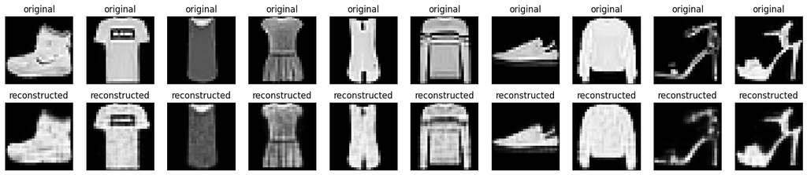

```python
visualize_new_features(X_train_fashion_mnist, X_train_fashion_mnist_decoded)
```

```python
X_test_fashion_mnist_encoded = autoencoder.encoder(X_test_fashion_mnist).numpy()
X_test_fashion_mnist_decoded = autoencoder.decoder(X_test_fashion_mnist_encoded).numpy()
```

[figure not shown]

```python
visualize_new_features(X_test_fashion_mnist, X_test_fashion_mnist_decoded)
```

**c) Kuzushiji-MNIST dataset**

```python
autoencoder.fit(X_train_kmnist, X_train_kmnist, epochs = 35, shuffle = True, validation_data = (X_test_kmnist, X_test_kmnist))
```

```
1875/1875 ━━━━━━━━━━━━━━━━━━━━ 4s 2ms/step - loss: 0.1511 - val_loss: 0.1390
1875/1875 ━━━━━━━━━━━━━━━━━━━━ 4s 2ms/step - loss: 0.1339 - val_loss: 0.1354
1875/1875 ━━━━━━━━━━━━━━━━━━━━ 4s 2ms/step - loss: 0.1302 - val_loss: 0.1333
1875/1875 ━━━━━━━━━━━━━━━━━━━━ 4s 2ms/step - loss: 0.1290 - val_loss: 0.1325
1875/1875 ━━━━━━━━━━━━━━━━━━━━ 4s 2ms/step - loss: 0.1281 - val_loss: 0.1316
1875/1875 ━━━━━━━━━━━━━━━━━━━━ 3s 2ms/step - loss: 0.1272 - val_loss: 0.1308
1875/1875 ━━━━━━━━━━━━━━━━━━━━ 3s 2ms/step - loss: 0.1268 - val_loss: 0.1303
1875/1875 ━━━━━━━━━━━━━━━━━━━━ 4s 2ms/step - loss: 0.1266 - val_loss: 0.1300
1875/1875 ━━━━━━━━━━━━━━━━━━━━ 4s 2ms/step - loss: 0.1262 - val_loss: 0.1298
1875/1875 ━━━━━━━━━━━━━━━━━━━━ 4s 2ms/step - loss: 0.1258 - val_loss: 0.1294
1875/1875 ━━━━━━━━━━━━━━━━━━━━ 4s 2ms/step - loss: 0.1258 - val_loss: 0.1297
1875/1875 ━━━━━━━━━━━━━━━━━━━━ 4s 2ms/step - loss: 0.1254 - val_loss: 0.1295
1875/1875 ━━━━━━━━━━━━━━━━━━━━ 4s 2ms/step - loss: 0.1252 - val_loss: 0.1292
1875/1875 ━━━━━━━━━━━━━━━━━━━━ 4s 2ms/step - loss: 0.1254 - val_loss: 0.1293
1875/1875 ━━━━━━━━━━━━━━━━━━━━ 4s 2ms/step - loss: 0.1254 - val_loss: 0.1291
1875/1875 ━━━━━━━━━━━━━━━━━━━━ 4s 2ms/step - loss: 0.1250 - val_loss: 0.1290
1875/1875 ━━━━━━━━━━━━━━━━━━━━ 4s 2ms/step - loss: 0.1251 - val_loss: 0.1289
1875/1875 ━━━━━━━━━━━━━━━━━━━━ 4s 2ms/step - loss: 0.1251 - val_loss: 0.1290
1875/1875 ━━━━━━━━━━━━━━━━━━━━ 4s 2ms/step - loss: 0.1252 - val_loss: 0.1290
1875/1875 ━━━━━━━━━━━━━━━━━━━━ 4s 2ms/step - loss: 0.1248 - val_loss: 0.1290
1875/1875 ━━━━━━━━━━━━━━━━━━━━ 4s 2ms/step - loss: 0.1249 - val_loss: 0.1289
1875/1875 ━━━━━━━━━━━━━━━━━━━━ 4s 2ms/step - loss: 0.1249 - val_loss: 0.1289
1875/1875 ━━━━━━━━━━━━━━━━━━━━ 4s 2ms/step - loss: 0.1249 - val_loss: 0.1286
1875/1875 ━━━━━━━━━━━━━━━━━━━━ 4s 2ms/step - loss: 0.1247 - val_loss: 0.1287
1875/1875 ━━━━━━━━━━━━━━━━━━━━ 4s 2ms/step - loss: 0.1246 - val_loss: 0.1289
1875/1875 ━━━━━━━━━━━━━━━━━━━━ 4s 2ms/step - loss: 0.1244 - val_loss: 0.1287
1875/1875 ━━━━━━━━━━━━━━━━━━━━ 4s 2ms/step - loss: 0.1246 - val_loss: 0.1288
1875/1875 ━━━━━━━━━━━━━━━━━━━━ 4s 2ms/step - loss: 0.1246 - val_loss: 0.1287
1875/1875 ━━━━━━━━━━━━━━━━━━━━ 4s 2ms/step - loss: 0.1245 - val_loss: 0.1284
1875/1875 ━━━━━━━━━━━━━━━━━━━━ 4s 2ms/step - loss: 0.1247 - val_loss: 0.1286
1875/1875 ━━━━━━━━━━━━━━━━━━━━ 4s 2ms/step - loss: 0.1247 - val_loss: 0.1284
1875/1875 ━━━━━━━━━━━━━━━━━━━━ 4s 2ms/step - loss: 0.1248 - val_loss: 0.1287
1875/1875 ━━━━━━━━━━━━━━━━━━━━ 4s 2ms/step - loss: 0.1244 - val_loss: 0.1285
1875/1875 ━━━━━━━━━━━━━━━━━━━━ 4s 2ms/step - loss: 0.1248 - val_loss: 0.1285
1875/1875 ━━━━━━━━━━━━━━━━━━━━ 4s 2ms/step - loss: 0.1246 - val_loss: 0.1285
```

```
<keras.src.callbacks.history.History at 0x1ee3a320e80>
```

```python
X_train_kmnist_encoded = autoencoder.encoder(X_train_kmnist).numpy()
X_train_kmnist_decoded = autoencoder.decoder(X_train_kmnist_encoded).numpy()
```

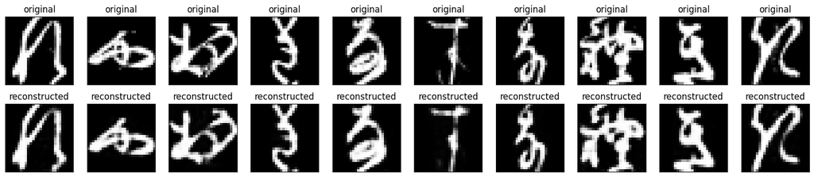

```python
visualize_new_features(X_train_kmnist, X_train_kmnist_decoded)
```

```python
X_test_kmnist_encoded = autoencoder.encoder(X_test_kmnist).numpy()
X_test_kmnist_decoded = autoencoder.decoder(X_test_kmnist_encoded).numpy()
```

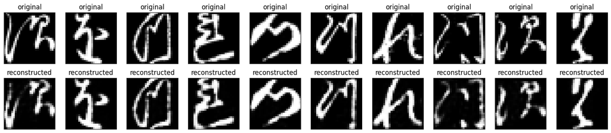

```python
visualize_new_features(X_test_kmnist, X_test_kmnist_decoded)
```

**d) Kuzushiji-49 dataset**

```python
autoencoder.fit(X_train_k49, X_train_k49, epochs = 35, shuffle = True, validation_data = (X_test_k49, X_test_k49))
```

```
7262/7262 ━━━━━━━━━━━━━━━━━━━━ 15s 2ms/step - loss: 0.1138 - val_loss: 0.1155
7262/7262 ━━━━━━━━━━━━━━━━━━━━ 14s 2ms/step - loss: 0.1136 - val_loss: 0.1153
7262/7262 ━━━━━━━━━━━━━━━━━━━━ 15s 2ms/step - loss: 0.1132 - val_loss: 0.1154
7262/7262 ━━━━━━━━━━━━━━━━━━━━ 15s 2ms/step - loss: 0.1131 - val_loss: 0.1152
7262/7262 ━━━━━━━━━━━━━━━━━━━━ 15s 2ms/step - loss: 0.1131 - val_loss: 0.1151
7262/7262 ━━━━━━━━━━━━━━━━━━━━ 15s 2ms/step - loss: 0.1133 - val_loss: 0.1151
7262/7262 ━━━━━━━━━━━━━━━━━━━━ 15s 2ms/step - loss: 0.1131 - val_loss: 0.1151
7262/7262 ━━━━━━━━━━━━━━━━━━━━ 15s 2ms/step - loss: 0.1130 - val_loss: 0.1152
7262/7262 ━━━━━━━━━━━━━━━━━━━━ 14s 2ms/step - loss: 0.1129 - val_loss: 0.1150
7262/7262 ━━━━━━━━━━━━━━━━━━━━ 15s 2ms/step - loss: 0.1130 - val_loss: 0.1150
7262/7262 ━━━━━━━━━━━━━━━━━━━━ 15s 2ms/step - loss: 0.1130 - val_loss: 0.1151
7262/7262 ━━━━━━━━━━━━━━━━━━━━ 15s 2ms/step - loss: 0.1129 - val_loss: 0.1149
7262/7262 ━━━━━━━━━━━━━━━━━━━━ 15s 2ms/step - loss: 0.1128 - val_loss: 0.1150
7262/7262 ━━━━━━━━━━━━━━━━━━━━ 15s 2ms/step - loss: 0.1128 - val_loss: 0.1149
7262/7262 ━━━━━━━━━━━━━━━━━━━━ 15s 2ms/step - loss: 0.1130 - val_loss: 0.1150
7262/7262 ━━━━━━━━━━━━━━━━━━━━ 15s 2ms/step - loss: 0.1129 - val_loss: 0.1149
7262/7262 ━━━━━━━━━━━━━━━━━━━━ 15s 2ms/step - loss: 0.1129 - val_loss: 0.1149
7262/7262 ━━━━━━━━━━━━━━━━━━━━ 15s 2ms/step - loss: 0.1128 - val_loss: 0.1149
7262/7262 ━━━━━━━━━━━━━━━━━━━━ 16s 2ms/step - loss: 0.1129 - val_loss: 0.1147
7262/7262 ━━━━━━━━━━━━━━━━━━━━ 16s 2ms/step - loss: 0.1128 - val_loss: 0.1148
7262/7262 ━━━━━━━━━━━━━━━━━━━━ 15s 2ms/step - loss: 0.1128 - val_loss: 0.1148
7262/7262 ━━━━━━━━━━━━━━━━━━━━ 15s 2ms/step - loss: 0.1127 - val_loss: 0.1148
7262/7262 ━━━━━━━━━━━━━━━━━━━━ 15s 2ms/step - loss: 0.1129 - val_loss: 0.1147
7262/7262 ━━━━━━━━━━━━━━━━━━━━ 15s 2ms/step - loss: 0.1128 - val_loss: 0.1148
7262/7262 ━━━━━━━━━━━━━━━━━━━━ 15s 2ms/step - loss: 0.1128 - val_loss: 0.1146
7262/7262 ━━━━━━━━━━━━━━━━━━━━ 15s 2ms/step - loss: 0.1127 - val_loss: 0.1146
7262/7262 ━━━━━━━━━━━━━━━━━━━━ 15s 2ms/step - loss: 0.1128 - val_loss: 0.1149
7262/7262 ━━━━━━━━━━━━━━━━━━━━ 15s 2ms/step - loss: 0.1128 - val_loss: 0.1146
7262/7262 ━━━━━━━━━━━━━━━━━━━━ 15s 2ms/step - loss: 0.1128 - val_loss: 0.1147
7262/7262 ━━━━━━━━━━━━━━━━━━━━ 15s 2ms/step - loss: 0.1127 - val_loss: 0.1147
7262/7262 ━━━━━━━━━━━━━━━━━━━━ 15s 2ms/step - loss: 0.1127 - val_loss: 0.1148
7262/7262 ━━━━━━━━━━━━━━━━━━━━ 15s 2ms/step - loss: 0.1127 - val_loss: 0.1147
7262/7262 ━━━━━━━━━━━━━━━━━━━━ 15s 2ms/step - loss: 0.1128 - val_loss: 0.1147
7262/7262 ━━━━━━━━━━━━━━━━━━━━ 15s 2ms/step - loss: 0.1127 - val_loss: 0.1147
7262/7262 ━━━━━━━━━━━━━━━━━━━━ 15s 2ms/step - loss: 0.1128 - val_loss: 0.1147
```

```
<keras.src.callbacks.history.History at 0x1ee3a2cb190>
```

```python
X_train_k49_encoded = autoencoder.encoder(X_train_k49).numpy()
X_train_k49_decoded = autoencoder.decoder(X_train_k49_encoded).numpy()
```

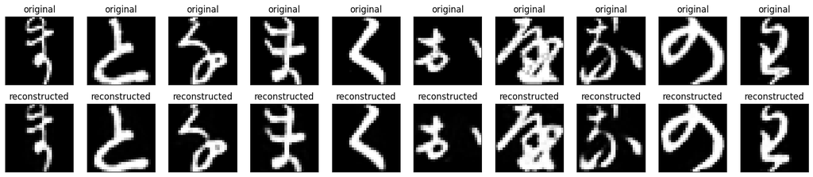

```python
visualize_new_features(X_train_k49, X_train_k49_decoded)
```

```python
X_test_k49_encoded = autoencoder.encoder(X_test_k49).numpy()
X_test_k49_decoded = autoencoder.decoder(X_test_k49_encoded).numpy()
```

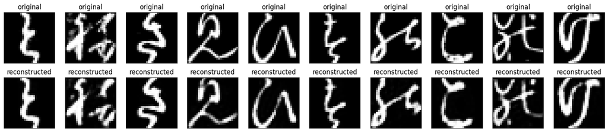

```python
visualize_new_features(X_test_k49, X_test_k49_decoded)
```

#### 4.5 Train the LogisticRegression classifier by setting solver=’newton-cg’. Make predictions on the test set and compare the obtained results with the results from sections 5 and 6. Will changing the classifier to RandomForestClassifier improve classification accuracy? Provide your comments on the overall classification results.

```python
logistic = LogisticRegression(solver = 'newton-cg', C = 0.1, random_state = 42)
```

```python
rfc = RandomForestClassifier(random_state = 42)
```

**a) MNIST dataset**

```python
logistic.fit(X_train_mnist_encoded, Y_train_mnist)
Y_pred_mnist = logistic.predict(X_test_mnist_encoded)
show_classification_metrics(Y_test_mnist, Y_pred_mnist)
```

|  | accuracy | precision | recall | f1-score |
| --- | --- | --- | --- | --- |
| 0 | 0.9925 | 0.950249 | 0.974490 | 0.962217 |
| 1 | 0.9947 | 0.973730 | 0.979736 | 0.976724 |
| 2 | 0.9821 | 0.921860 | 0.903101 | 0.912384 |
| 3 | 0.9810 | 0.900391 | 0.912871 | 0.906588 |
| 4 | 0.9857 | 0.927625 | 0.926680 | 0.927152 |
| 5 | 0.9798 | 0.900232 | 0.869955 | 0.884835 |
| 6 | 0.9889 | 0.939772 | 0.944676 | 0.942218 |
| 7 | 0.9840 | 0.923002 | 0.921206 | 0.922103 |
| 8 | 0.9774 | 0.880855 | 0.888090 | 0.884458 |
| 9 | 0.9809 | 0.907371 | 0.902874 | 0.905117 |
| aggregated | 0.9847 | 0.923500 | 0.923500 | 0.923500 |

```python
rfc.fit(X_train_mnist_encoded, Y_train_mnist)
Y_pred_mnist_rfc = rfc.predict(X_test_mnist_encoded)
show_classification_metrics(Y_test_mnist, Y_pred_mnist_rfc)
```

|  | accuracy | precision | recall | f1-score |
| --- | --- | --- | --- | --- |
| 0 | 0.99390 | 0.959041 | 0.979592 | 0.969207 |
| 1 | 0.99660 | 0.985878 | 0.984141 | 0.985009 |
| 2 | 0.98520 | 0.929126 | 0.927326 | 0.928225 |
| 3 | 0.98370 | 0.908390 | 0.932673 | 0.920371 |
| 4 | 0.98710 | 0.917728 | 0.954175 | 0.935597 |
| 5 | 0.98350 | 0.926143 | 0.885650 | 0.905444 |
| 6 | 0.99070 | 0.944502 | 0.959290 | 0.951838 |
| 7 | 0.98690 | 0.946269 | 0.925097 | 0.935563 |
| 8 | 0.98140 | 0.914737 | 0.892197 | 0.903326 |
| 9 | 0.98420 | 0.926780 | 0.915758 | 0.921236 |
| aggregated | 0.98732 | 0.936600 | 0.936600 | 0.936600 |

**b) Fashion-MNIST dataset**

```python
logistic.fit(X_train_fashion_mnist_encoded, Y_train_fashion_mnist)
Y_pred_fashion_mnist = logistic.predict(X_test_fashion_mnist_encoded)
show_classification_metrics(Y_test_fashion_mnist, Y_pred_fashion_mnist)
```

|  | accuracy | precision | recall | f1-score |
| --- | --- | --- | --- | --- |
| 0 | 0.96150 | 0.805362 | 0.8110 | 0.808171 |
| 1 | 0.99440 | 0.983607 | 0.9600 | 0.971660 |
| 2 | 0.94700 | 0.724237 | 0.7590 | 0.741211 |
| 3 | 0.97220 | 0.851852 | 0.8740 | 0.862784 |
| 4 | 0.95040 | 0.747544 | 0.7610 | 0.754212 |
| 5 | 0.99080 | 0.963265 | 0.9440 | 0.953535 |
| 6 | 0.92500 | 0.637363 | 0.5800 | 0.607330 |
| 7 | 0.98660 | 0.923679 | 0.9440 | 0.933729 |
| 8 | 0.99140 | 0.953373 | 0.9610 | 0.957171 |
| 9 | 0.98990 | 0.947264 | 0.9520 | 0.949626 |
| aggregated | 0.97092 | 0.854600 | 0.8546 | 0.854600 |

```python
rfc.fit(X_train_fashion_mnist_encoded, Y_train_fashion_mnist)
Y_pred_fashion_mnist_rfc = rfc.predict(X_test_fashion_mnist_encoded)
show_classification_metrics(Y_test_fashion_mnist, Y_pred_fashion_mnist_rfc)
```

|  | accuracy | precision | recall | f1-score |
| --- | --- | --- | --- | --- |
| 0 | 0.9636 | 0.806950 | 0.8360 | 0.821218 |
| 1 | 0.9941 | 0.996832 | 0.9440 | 0.969697 |
| 2 | 0.9515 | 0.751711 | 0.7690 | 0.760257 |
| 3 | 0.9727 | 0.838140 | 0.9010 | 0.868434 |
| 4 | 0.9527 | 0.743756 | 0.8040 | 0.772705 |
| 5 | 0.9877 | 0.945178 | 0.9310 | 0.938035 |
| 6 | 0.9329 | 0.704857 | 0.5660 | 0.627842 |
| 7 | 0.9853 | 0.921027 | 0.9330 | 0.926975 |
| 8 | 0.9914 | 0.941973 | 0.9740 | 0.957719 |
| 9 | 0.9871 | 0.934197 | 0.9370 | 0.935597 |
| aggregated | 0.9719 | 0.859500 | 0.8595 | 0.859500 |

**c) Kuzushiji-MNIST dataset**

```python
logistic.fit(X_train_kmnist_encoded, Y_train_kmnist)
Y_pred_kmnist = logistic.predict(X_test_kmnist_encoded)
show_classification_metrics(Y_test_kmnist, Y_pred_kmnist)
```

|  | accuracy | precision | recall | f1-score |
| --- | --- | --- | --- | --- |
| 0 | 0.96820 | 0.868251 | 0.8040 | 0.834891 |
| 1 | 0.93900 | 0.689689 | 0.7090 | 0.699211 |
| 2 | 0.91530 | 0.565778 | 0.6580 | 0.608414 |
| 3 | 0.96120 | 0.801181 | 0.8140 | 0.807540 |
| 4 | 0.93580 | 0.682653 | 0.6690 | 0.675758 |
| 5 | 0.95300 | 0.802511 | 0.7030 | 0.749467 |
| 6 | 0.94570 | 0.712558 | 0.7660 | 0.738313 |
| 7 | 0.95000 | 0.805623 | 0.6590 | 0.724972 |
| 8 | 0.93890 | 0.666667 | 0.7780 | 0.718043 |
| 9 | 0.94710 | 0.747634 | 0.7110 | 0.728857 |
| aggregated | 0.94542 | 0.727100 | 0.7271 | 0.727100 |

```python
rfc.fit(X_train_kmnist_encoded, Y_train_kmnist)
Y_pred_kmnist_rfc = rfc.predict(X_test_kmnist_encoded)
show_classification_metrics(Y_test_kmnist, Y_pred_kmnist_rfc)
```

|  | accuracy | precision | recall | f1-score |
| --- | --- | --- | --- | --- |
| 0 | 0.9675 | 0.849018 | 0.8210 | 0.834774 |
| 1 | 0.9552 | 0.773267 | 0.7810 | 0.777114 |
| 2 | 0.9356 | 0.661818 | 0.7280 | 0.693333 |
| 3 | 0.9715 | 0.836312 | 0.8890 | 0.861852 |
| 4 | 0.9299 | 0.631718 | 0.7170 | 0.671663 |
| 5 | 0.9650 | 0.924282 | 0.7080 | 0.801812 |
| 6 | 0.9573 | 0.758341 | 0.8410 | 0.797534 |
| 7 | 0.9476 | 0.805913 | 0.6270 | 0.705287 |
| 8 | 0.9552 | 0.742105 | 0.8460 | 0.790654 |
| 9 | 0.9542 | 0.790773 | 0.7370 | 0.762940 |
| aggregated | 0.9539 | 0.769500 | 0.7695 | 0.769500 |

**d) Kuzushiji-49 dataset**

```python
logistic.fit(X_train_k49_encoded, Y_train_k49)
Y_pred_k49 = logistic.predict(X_test_k49_encoded)
show_classification_metrics(Y_test_k49, Y_pred_k49)
```

|  | accuracy | precision | recall | f1-score |
| --- | --- | --- | --- | --- |
| 0 | 0.977430 | 0.561205 | 0.596000 | 0.578080 |
| 1 | 0.990064 | 0.802748 | 0.818000 | 0.810302 |
| 2 | 0.985291 | 0.676735 | 0.829000 | 0.745169 |
| 3 | 0.997146 | 0.558824 | 0.603175 | 0.580153 |
| 4 | 0.984564 | 0.711157 | 0.682000 | 0.696274 |
| 5 | 0.976133 | 0.553908 | 0.411000 | 0.471871 |
| 6 | 0.975614 | 0.531315 | 0.509000 | 0.519918 |
| 7 | 0.982463 | 0.639415 | 0.743000 | 0.687327 |
| 8 | 0.976081 | 0.401774 | 0.413299 | 0.407455 |
| 9 | 0.980439 | 0.638202 | 0.568000 | 0.601058 |
| 10 | 0.983397 | 0.704545 | 0.620000 | 0.659574 |
| 11 | 0.985109 | 0.728541 | 0.679000 | 0.702899 |
| 12 | 0.963084 | 0.333333 | 0.423000 | 0.372851 |
| 13 | 0.987548 | 0.679348 | 0.553097 | 0.609756 |
| 14 | 0.986484 | 0.605469 | 0.492846 | 0.543383 |
| 15 | 0.974110 | 0.500945 | 0.530000 | 0.515063 |
| 16 | 0.994474 | 0.721382 | 0.799043 | 0.758229 |
| 17 | 0.979635 | 0.602479 | 0.632000 | 0.616886 |
| 18 | 0.985135 | 0.687445 | 0.783000 | 0.732118 |
| 19 | 0.979713 | 0.611452 | 0.598000 | 0.604651 |
| 20 | 0.975173 | 0.522466 | 0.500000 | 0.510986 |
| 21 | 0.975977 | 0.535171 | 0.563000 | 0.548733 |
| 22 | 0.992477 | 0.570988 | 0.550595 | 0.560606 |
| 23 | 0.989052 | 0.473441 | 0.513784 | 0.492788 |
| 24 | 0.979895 | 0.607041 | 0.638000 | 0.622136 |
| 25 | 0.978598 | 0.625538 | 0.436000 | 0.513848 |
| 26 | 0.988274 | 0.740000 | 0.708134 | 0.723716 |
| 27 | 0.986095 | 0.780193 | 0.646000 | 0.706783 |
| 28 | 0.991569 | 0.887486 | 0.773000 | 0.826296 |
| 29 | 0.991387 | 0.484252 | 0.379630 | 0.425606 |
| 30 | 0.975640 | 0.527552 | 0.584000 | 0.554343 |
| 31 | 0.987522 | 0.520190 | 0.439759 | 0.476605 |
| 32 | 0.995123 | 0.653333 | 0.700000 | 0.675862 |
| 33 | 0.989493 | 0.652807 | 0.568841 | 0.607938 |
| 34 | 0.975433 | 0.521883 | 0.632000 | 0.571687 |
| 35 | 0.979194 | 0.621921 | 0.505000 | 0.557395 |
| 36 | 0.993307 | 0.503650 | 0.530769 | 0.516854 |
| 37 | 0.988508 | 0.741126 | 0.856000 | 0.794432 |
| 38 | 0.975277 | 0.518431 | 0.661000 | 0.581099 |
| 39 | 0.972320 | 0.467943 | 0.489000 | 0.478240 |
| 40 | 0.974187 | 0.502924 | 0.430000 | 0.463612 |
| 41 | 0.975069 | 0.517272 | 0.584000 | 0.548614 |
| 42 | 0.991906 | 0.551429 | 0.554598 | 0.553009 |
| 43 | 0.990739 | 0.560440 | 0.392308 | 0.461538 |
| 44 | 0.998132 | 0.452381 | 0.279412 | 0.345455 |
| 45 | 0.998703 | 0.659091 | 0.453125 | 0.537037 |
| 46 | 0.979402 | 0.597353 | 0.632000 | 0.614189 |
| 47 | 0.990946 | 0.777021 | 0.913000 | 0.839540 |
| 48 | 0.988508 | 0.631263 | 0.548780 | 0.587139 |
| aggregated | 0.983915 | 0.605910 | 0.605910 | 0.605910 |

```python
rfc.fit(X_train_k49_encoded, Y_train_k49)
Y_pred_k49_rfc = rfc.predict(X_test_k49_encoded)
show_classification_metrics(Y_test_k49, Y_pred_k49_rfc)
```

|  | accuracy | precision | recall | f1-score |
| --- | --- | --- | --- | --- |
| 0 | 0.978753 | 0.562543 | 0.814000 | 0.665304 |
| 1 | 0.992606 | 0.849462 | 0.869000 | 0.859120 |
| 2 | 0.989000 | 0.729665 | 0.915000 | 0.811890 |
| 3 | 0.998158 | 0.823529 | 0.555556 | 0.663507 |
| 4 | 0.984357 | 0.667228 | 0.792000 | 0.724280 |
| 5 | 0.983682 | 0.737516 | 0.576000 | 0.646828 |
| 6 | 0.980906 | 0.622905 | 0.669000 | 0.645130 |
| 7 | 0.989312 | 0.782150 | 0.815000 | 0.798237 |
| 8 | 0.978805 | 0.474120 | 0.597132 | 0.528563 |
| 9 | 0.984045 | 0.714127 | 0.642000 | 0.676145 |
| 10 | 0.983345 | 0.673786 | 0.694000 | 0.683744 |
| 11 | 0.989156 | 0.860149 | 0.695000 | 0.768805 |
| 12 | 0.977430 | 0.558559 | 0.620000 | 0.587678 |
| 13 | 0.985732 | 0.592486 | 0.604720 | 0.598540 |
| 14 | 0.987755 | 0.668094 | 0.496025 | 0.569343 |
| 15 | 0.982696 | 0.674346 | 0.644000 | 0.658824 |
| 16 | 0.995823 | 0.773987 | 0.868421 | 0.818489 |
| 17 | 0.984305 | 0.668372 | 0.784000 | 0.721583 |
| 18 | 0.987210 | 0.716482 | 0.839000 | 0.772916 |
| 19 | 0.986510 | 0.745902 | 0.728000 | 0.736842 |
| 20 | 0.975173 | 0.518113 | 0.615000 | 0.562414 |
| 21 | 0.982307 | 0.652008 | 0.682000 | 0.666667 |
| 22 | 0.994422 | 0.757447 | 0.529762 | 0.623468 |
| 23 | 0.992399 | 0.655882 | 0.558897 | 0.603518 |
| 24 | 0.986276 | 0.730205 | 0.747000 | 0.738507 |
| 25 | 0.987677 | 0.910798 | 0.582000 | 0.710189 |
| 26 | 0.988482 | 0.729508 | 0.745215 | 0.737278 |
| 27 | 0.986977 | 0.770652 | 0.709000 | 0.738542 |
| 28 | 0.993047 | 0.927570 | 0.794000 | 0.855603 |
| 29 | 0.994059 | 0.832168 | 0.367284 | 0.509636 |
| 30 | 0.979791 | 0.590204 | 0.723000 | 0.649888 |
| 31 | 0.992788 | 0.859477 | 0.528112 | 0.654229 |
| 32 | 0.995356 | 0.707819 | 0.614286 | 0.657744 |
| 33 | 0.990816 | 0.759162 | 0.525362 | 0.620985 |
| 34 | 0.986432 | 0.709763 | 0.807000 | 0.755264 |
| 35 | 0.979350 | 0.611111 | 0.561000 | 0.584984 |
| 36 | 0.996057 | 0.869863 | 0.488462 | 0.625616 |
| 37 | 0.988663 | 0.722530 | 0.914000 | 0.807064 |
| 38 | 0.988352 | 0.744889 | 0.838000 | 0.788706 |
| 39 | 0.986328 | 0.735793 | 0.738000 | 0.736895 |
| 40 | 0.984071 | 0.731415 | 0.610000 | 0.665213 |
| 41 | 0.984461 | 0.695610 | 0.713000 | 0.704198 |
| 42 | 0.994708 | 0.797521 | 0.554598 | 0.654237 |
| 43 | 0.993540 | 0.854271 | 0.435897 | 0.577250 |
| 44 | 0.998314 | 1.000000 | 0.044118 | 0.084507 |
| 45 | 0.998547 | 1.000000 | 0.125000 | 0.222222 |
| 46 | 0.985369 | 0.714567 | 0.726000 | 0.720238 |
| 47 | 0.992139 | 0.791145 | 0.947000 | 0.862085 |
| 48 | 0.993281 | 0.874109 | 0.641115 | 0.739698 |
| aggregated | 0.987934 | 0.704387 | 0.704387 | 0.704387 |

The Autoencoder enhanced feature representation, leading to improved performance for Logistic Regression. The feature extraction allowed the model to work with more compact and informative data. Replacing Logistic Regression with a Random Forest Classifier resulted in further performance improvement, as Random Forests are well-suited for handling complex feature relationships. They likely benefited from the compact feature space created by the Autoencoder. The overall results were satisfying. The combination of Autoencoders for feature extraction and a Random Forest Classifier for classification showed significant improvement, suggesting that Autoencoders can be highly effective in pre-processing data, especially for classification tasks.

#### 4.7 Propose your own deep Autoencoder architecture using convolutional filters. The new approach to feature extraction should improve classification accuracy on all datasets.

```python
input = layers.Input(shape = (28, 28, 1))

x = layers.Conv2D(32, (3, 3), activation = 'relu', padding = 'same')(input)
x = layers.MaxPooling2D((2, 2), padding = 'same')(x)
x = layers.Conv2D(32, (3, 3), activation = 'relu', padding = 'same')(x)
x = layers.MaxPooling2D((2, 2), padding = 'same')(x)

x = layers.Conv2DTranspose(32, (3, 3), strides = 2, activation = 'relu', padding = 'same')(x)
x = layers.Conv2DTranspose(32, (3, 3), strides = 2, activation = 'relu', padding = 'same')(x)
x = layers.Conv2D(1, (3, 3), activation = 'sigmoid', padding = 'same')(x)

output = layers.Dense(10, activation='softmax')(x)

model = Model(input, output)
model.compile(optimizer = 'adam', loss = 'categorical_crossentropy', metrics = ['accuracy'])
```

**a) MNIST dataset**

```python
autoencoder.fit(X_train_mnist, X_train_mnist, epochs = 35, shuffle = True, validation_data = (X_test_mnist, X_test_mnist))
X_train_mnist_encoded = autoencoder.predict(X_train_mnist)
X_test_mnist_encoded = autoencoder.predict(X_test_mnist)
```

```
1875/1875 ━━━━━━━━━━━━━━━━━━━━ 3s 2ms/step - loss: 0.0665 - val_loss: 0.0655
1875/1875 ━━━━━━━━━━━━━━━━━━━━ 3s 2ms/step - loss: 0.0657 - val_loss: 0.0652
1875/1875 ━━━━━━━━━━━━━━━━━━━━ 4s 2ms/step - loss: 0.0655 - val_loss: 0.0650
1875/1875 ━━━━━━━━━━━━━━━━━━━━ 3s 2ms/step - loss: 0.0653 - val_loss: 0.0648
1875/1875 ━━━━━━━━━━━━━━━━━━━━ 3s 2ms/step - loss: 0.0651 - val_loss: 0.0648
1875/1875 ━━━━━━━━━━━━━━━━━━━━ 3s 2ms/step - loss: 0.0649 - val_loss: 0.0647
1875/1875 ━━━━━━━━━━━━━━━━━━━━ 4s 2ms/step - loss: 0.0648 - val_loss: 0.0646
1875/1875 ━━━━━━━━━━━━━━━━━━━━ 4s 2ms/step - loss: 0.0647 - val_loss: 0.0645
1875/1875 ━━━━━━━━━━━━━━━━━━━━ 3s 2ms/step - loss: 0.0647 - val_loss: 0.0645
1875/1875 ━━━━━━━━━━━━━━━━━━━━ 3s 2ms/step - loss: 0.0646 - val_loss: 0.0644
1875/1875 ━━━━━━━━━━━━━━━━━━━━ 4s 2ms/step - loss: 0.0645 - val_loss: 0.0644
1875/1875 ━━━━━━━━━━━━━━━━━━━━ 4s 2ms/step - loss: 0.0645 - val_loss: 0.0644
1875/1875 ━━━━━━━━━━━━━━━━━━━━ 4s 2ms/step - loss: 0.0644 - val_loss: 0.0643
1875/1875 ━━━━━━━━━━━━━━━━━━━━ 4s 2ms/step - loss: 0.0645 - val_loss: 0.0643
1875/1875 ━━━━━━━━━━━━━━━━━━━━ 4s 2ms/step - loss: 0.0644 - val_loss: 0.0642
1875/1875 ━━━━━━━━━━━━━━━━━━━━ 4s 2ms/step - loss: 0.0644 - val_loss: 0.0642
1875/1875 ━━━━━━━━━━━━━━━━━━━━ 4s 2ms/step - loss: 0.0643 - val_loss: 0.0642
1875/1875 ━━━━━━━━━━━━━━━━━━━━ 4s 2ms/step - loss: 0.0643 - val_loss: 0.0642
1875/1875 ━━━━━━━━━━━━━━━━━━━━ 4s 2ms/step - loss: 0.0642 - val_loss: 0.0642
1875/1875 ━━━━━━━━━━━━━━━━━━━━ 4s 2ms/step - loss: 0.0643 - val_loss: 0.0642
1875/1875 ━━━━━━━━━━━━━━━━━━━━ 4s 2ms/step - loss: 0.0641 - val_loss: 0.0642
1875/1875 ━━━━━━━━━━━━━━━━━━━━ 4s 2ms/step - loss: 0.0642 - val_loss: 0.0642
1875/1875 ━━━━━━━━━━━━━━━━━━━━ 4s 2ms/step - loss: 0.0642 - val_loss: 0.0641
1875/1875 ━━━━━━━━━━━━━━━━━━━━ 5s 2ms/step - loss: 0.0642 - val_loss: 0.0642
1875/1875 ━━━━━━━━━━━━━━━━━━━━ 4s 2ms/step - loss: 0.0641 - val_loss: 0.0641
1875/1875 ━━━━━━━━━━━━━━━━━━━━ 4s 2ms/step - loss: 0.0641 - val_loss: 0.0641
1875/1875 ━━━━━━━━━━━━━━━━━━━━ 4s 2ms/step - loss: 0.0643 - val_loss: 0.0642
1875/1875 ━━━━━━━━━━━━━━━━━━━━ 4s 2ms/step - loss: 0.0641 - val_loss: 0.0641
1875/1875 ━━━━━━━━━━━━━━━━━━━━ 4s 2ms/step - loss: 0.0641 - val_loss: 0.0641
1875/1875 ━━━━━━━━━━━━━━━━━━━━ 4s 2ms/step - loss: 0.0641 - val_loss: 0.0642
1875/1875 ━━━━━━━━━━━━━━━━━━━━ 4s 2ms/step - loss: 0.0641 - val_loss: 0.0641
1875/1875 ━━━━━━━━━━━━━━━━━━━━ 4s 2ms/step - loss: 0.0642 - val_loss: 0.0641
1875/1875 ━━━━━━━━━━━━━━━━━━━━ 4s 2ms/step - loss: 0.0641 - val_loss: 0.0641
1875/1875 ━━━━━━━━━━━━━━━━━━━━ 4s 2ms/step - loss: 0.0641 - val_loss: 0.0641
1875/1875 ━━━━━━━━━━━━━━━━━━━━ 4s 2ms/step - loss: 0.0641 - val_loss: 0.0641
1875/1875 ━━━━━━━━━━━━━━━━━━━━ 1s 658us/step
313/313 ━━━━━━━━━━━━━━━━━━━━ 0s 773us/step
```

```python
X_train_mnist_encoded = X_train_mnist_encoded.reshape(X_train_mnist_encoded.shape[0], -1)
X_test_mnist_encoded = X_test_mnist_encoded.reshape(X_test_mnist_encoded.shape[0], -1)
```

```python
rfc = RandomForestClassifier(random_state = 42)
rfc.fit(X_train_mnist_encoded, Y_train_mnist)
Y_pred_mnist = rfc.predict(X_test_mnist_encoded)
show_classification_metrics(Y_test_mnist, Y_pred_mnist)
```

|  | accuracy | precision | recall | f1-score |
| --- | --- | --- | --- | --- |
| 0 | 0.99520 | 0.965070 | 0.986735 | 0.975782 |
| 1 | 0.99640 | 0.984141 | 0.984141 | 0.984141 |
| 2 | 0.99170 | 0.959342 | 0.960271 | 0.959806 |
| 3 | 0.99090 | 0.950049 | 0.960396 | 0.955194 |
| 4 | 0.98990 | 0.942714 | 0.955193 | 0.948912 |
| 5 | 0.99260 | 0.971198 | 0.945067 | 0.957955 |
| 6 | 0.99480 | 0.971875 | 0.973904 | 0.972888 |
| 7 | 0.99220 | 0.970297 | 0.953307 | 0.961727 |
| 8 | 0.99030 | 0.952528 | 0.947639 | 0.950077 |
| 9 | 0.98660 | 0.934459 | 0.932607 | 0.933532 |
| aggregated | 0.99206 | 0.960300 | 0.960300 | 0.960300 |

**b) Fashion-MNIST dataset**

```python
autoencoder.fit(X_train_fashion_mnist, X_train_fashion_mnist, epochs = 35, shuffle = True, validation_data = (X_test_fashion_mnist,
                                                                                                              X_test_fashion_mnist))

X_train_fashion_mnist_encoded = autoencoder.predict(X_train_fashion_mnist)
X_test_fashion_mnist_encoded = autoencoder.predict(X_test_fashion_mnist)
X_train_fashion_mnist_encoded = X_train_fashion_mnist_encoded.reshape(X_train_fashion_mnist_encoded.shape[0], -1)
X_test_fashion_mnist_encoded = X_test_fashion_mnist_encoded.reshape(X_test_fashion_mnist_encoded.shape[0], -1)
```

```
1875/1875 ━━━━━━━━━━━━━━━━━━━━ 4s 2ms/step - loss: 0.3143 - val_loss: 0.2712
1875/1875 ━━━━━━━━━━━━━━━━━━━━ 4s 2ms/step - loss: 0.2671 - val_loss: 0.2656
1875/1875 ━━━━━━━━━━━━━━━━━━━━ 4s 2ms/step - loss: 0.2623 - val_loss: 0.2631
1875/1875 ━━━━━━━━━━━━━━━━━━━━ 4s 2ms/step - loss: 0.2600 - val_loss: 0.2616
1875/1875 ━━━━━━━━━━━━━━━━━━━━ 4s 2ms/step - loss: 0.2591 - val_loss: 0.2609
1875/1875 ━━━━━━━━━━━━━━━━━━━━ 4s 2ms/step - loss: 0.2584 - val_loss: 0.2603
1875/1875 ━━━━━━━━━━━━━━━━━━━━ 4s 2ms/step - loss: 0.2583 - val_loss: 0.2598
1875/1875 ━━━━━━━━━━━━━━━━━━━━ 4s 2ms/step - loss: 0.2569 - val_loss: 0.2597
1875/1875 ━━━━━━━━━━━━━━━━━━━━ 4s 2ms/step - loss: 0.2568 - val_loss: 0.2595
1875/1875 ━━━━━━━━━━━━━━━━━━━━ 4s 2ms/step - loss: 0.2566 - val_loss: 0.2593
1875/1875 ━━━━━━━━━━━━━━━━━━━━ 4s 2ms/step - loss: 0.2563 - val_loss: 0.2592
1875/1875 ━━━━━━━━━━━━━━━━━━━━ 4s 2ms/step - loss: 0.2566 - val_loss: 0.2590
1875/1875 ━━━━━━━━━━━━━━━━━━━━ 4s 2ms/step - loss: 0.2569 - val_loss: 0.2588
1875/1875 ━━━━━━━━━━━━━━━━━━━━ 4s 2ms/step - loss: 0.2558 - val_loss: 0.2589
1875/1875 ━━━━━━━━━━━━━━━━━━━━ 4s 2ms/step - loss: 0.2564 - val_loss: 0.2586
1875/1875 ━━━━━━━━━━━━━━━━━━━━ 4s 2ms/step - loss: 0.2562 - val_loss: 0.2587
1875/1875 ━━━━━━━━━━━━━━━━━━━━ 4s 2ms/step - loss: 0.2554 - val_loss: 0.2588
1875/1875 ━━━━━━━━━━━━━━━━━━━━ 4s 2ms/step - loss: 0.2553 - val_loss: 0.2585
1875/1875 ━━━━━━━━━━━━━━━━━━━━ 4s 2ms/step - loss: 0.2559 - val_loss: 0.2586
1875/1875 ━━━━━━━━━━━━━━━━━━━━ 4s 2ms/step - loss: 0.2564 - val_loss: 0.2588
1875/1875 ━━━━━━━━━━━━━━━━━━━━ 4s 2ms/step - loss: 0.2561 - val_loss: 0.2587
1875/1875 ━━━━━━━━━━━━━━━━━━━━ 4s 2ms/step - loss: 0.2554 - val_loss: 0.2586
1875/1875 ━━━━━━━━━━━━━━━━━━━━ 4s 2ms/step - loss: 0.2551 - val_loss: 0.2584
1875/1875 ━━━━━━━━━━━━━━━━━━━━ 4s 2ms/step - loss: 0.2555 - val_loss: 0.2584
1875/1875 ━━━━━━━━━━━━━━━━━━━━ 4s 2ms/step - loss: 0.2562 - val_loss: 0.2584
1875/1875 ━━━━━━━━━━━━━━━━━━━━ 4s 2ms/step - loss: 0.2565 - val_loss: 0.2585
1875/1875 ━━━━━━━━━━━━━━━━━━━━ 4s 2ms/step - loss: 0.2557 - val_loss: 0.2583
1875/1875 ━━━━━━━━━━━━━━━━━━━━ 4s 2ms/step - loss: 0.2556 - val_loss: 0.2584
1875/1875 ━━━━━━━━━━━━━━━━━━━━ 4s 2ms/step - loss: 0.2561 - val_loss: 0.2583
1875/1875 ━━━━━━━━━━━━━━━━━━━━ 4s 2ms/step - loss: 0.2554 - val_loss: 0.2583
1875/1875 ━━━━━━━━━━━━━━━━━━━━ 4s 2ms/step - loss: 0.2559 - val_loss: 0.2583
1875/1875 ━━━━━━━━━━━━━━━━━━━━ 4s 2ms/step - loss: 0.2556 - val_loss: 0.2583
1875/1875 ━━━━━━━━━━━━━━━━━━━━ 4s 2ms/step - loss: 0.2556 - val_loss: 0.2583
1875/1875 ━━━━━━━━━━━━━━━━━━━━ 4s 2ms/step - loss: 0.2557 - val_loss: 0.2583
1875/1875 ━━━━━━━━━━━━━━━━━━━━ 4s 2ms/step - loss: 0.2561 - val_loss: 0.2583
1875/1875 ━━━━━━━━━━━━━━━━━━━━ 1s 653us/step
313/313 ━━━━━━━━━━━━━━━━━━━━ 0s 680us/step
```

```python
rfc.fit(X_train_fashion_mnist_encoded, Y_train_fashion_mnist)
Y_pred_fashion_mnist = rfc.predict(X_test_fashion_mnist_encoded)
show_classification_metrics(Y_test_fashion_mnist, Y_pred_fashion_mnist)
```

|  | accuracy | precision | recall | f1-score |
| --- | --- | --- | --- | --- |
| 0 | 0.96560 | 0.816602 | 0.8460 | 0.831041 |
| 1 | 0.99460 | 0.993737 | 0.9520 | 0.972421 |
| 2 | 0.95580 | 0.768269 | 0.7990 | 0.783333 |
| 3 | 0.97540 | 0.863900 | 0.8950 | 0.879175 |
| 4 | 0.95660 | 0.769011 | 0.8090 | 0.788499 |
| 5 | 0.99140 | 0.966327 | 0.9470 | 0.956566 |
| 6 | 0.93420 | 0.699301 | 0.6000 | 0.645856 |
| 7 | 0.98690 | 0.919807 | 0.9520 | 0.935627 |
| 8 | 0.99220 | 0.951961 | 0.9710 | 0.961386 |
| 9 | 0.98950 | 0.954315 | 0.9400 | 0.947103 |
| aggregated | 0.97422 | 0.871100 | 0.8711 | 0.871100 |

**c) Kuzushiji-MNIST dataset**

```python
autoencoder.fit(X_train_kmnist, X_train_kmnist, epochs = 35, shuffle = True, validation_data = (X_test_kmnist, X_test_kmnist))
X_train_kmnist_encoded = autoencoder.predict(X_train_kmnist)
X_test_kmnist_encoded = autoencoder.predict(X_test_kmnist)
X_train_kmnist_encoded = X_train_kmnist_encoded.reshape(X_train_kmnist_encoded.shape[0], -1)
X_test_kmnist_encoded = X_test_kmnist_encoded.reshape(X_test_kmnist_encoded.shape[0], -1)
```

```
1875/1875 ━━━━━━━━━━━━━━━━━━━━ 4s 2ms/step - loss: 0.1496 - val_loss: 0.1382
1875/1875 ━━━━━━━━━━━━━━━━━━━━ 4s 2ms/step - loss: 0.1329 - val_loss: 0.1347
1875/1875 ━━━━━━━━━━━━━━━━━━━━ 4s 2ms/step - loss: 0.1300 - val_loss: 0.1329
1875/1875 ━━━━━━━━━━━━━━━━━━━━ 4s 2ms/step - loss: 0.1289 - val_loss: 0.1319
1875/1875 ━━━━━━━━━━━━━━━━━━━━ 4s 2ms/step - loss: 0.1278 - val_loss: 0.1311
1875/1875 ━━━━━━━━━━━━━━━━━━━━ 4s 2ms/step - loss: 0.1268 - val_loss: 0.1307
1875/1875 ━━━━━━━━━━━━━━━━━━━━ 3s 2ms/step - loss: 0.1267 - val_loss: 0.1305
1875/1875 ━━━━━━━━━━━━━━━━━━━━ 3s 2ms/step - loss: 0.1262 - val_loss: 0.1300
1875/1875 ━━━━━━━━━━━━━━━━━━━━ 4s 2ms/step - loss: 0.1262 - val_loss: 0.1299
1875/1875 ━━━━━━━━━━━━━━━━━━━━ 4s 2ms/step - loss: 0.1260 - val_loss: 0.1297
1875/1875 ━━━━━━━━━━━━━━━━━━━━ 4s 2ms/step - loss: 0.1258 - val_loss: 0.1297
1875/1875 ━━━━━━━━━━━━━━━━━━━━ 4s 2ms/step - loss: 0.1259 - val_loss: 0.1296
1875/1875 ━━━━━━━━━━━━━━━━━━━━ 4s 2ms/step - loss: 0.1255 - val_loss: 0.1295
1875/1875 ━━━━━━━━━━━━━━━━━━━━ 4s 2ms/step - loss: 0.1256 - val_loss: 0.1294
1875/1875 ━━━━━━━━━━━━━━━━━━━━ 4s 2ms/step - loss: 0.1255 - val_loss: 0.1294
1875/1875 ━━━━━━━━━━━━━━━━━━━━ 4s 2ms/step - loss: 0.1251 - val_loss: 0.1292
1875/1875 ━━━━━━━━━━━━━━━━━━━━ 4s 2ms/step - loss: 0.1251 - val_loss: 0.1293
1875/1875 ━━━━━━━━━━━━━━━━━━━━ 4s 2ms/step - loss: 0.1252 - val_loss: 0.1293
1875/1875 ━━━━━━━━━━━━━━━━━━━━ 4s 2ms/step - loss: 0.1252 - val_loss: 0.1293
1875/1875 ━━━━━━━━━━━━━━━━━━━━ 4s 2ms/step - loss: 0.1251 - val_loss: 0.1292
1875/1875 ━━━━━━━━━━━━━━━━━━━━ 4s 2ms/step - loss: 0.1250 - val_loss: 0.1291
1875/1875 ━━━━━━━━━━━━━━━━━━━━ 4s 2ms/step - loss: 0.1248 - val_loss: 0.1290
1875/1875 ━━━━━━━━━━━━━━━━━━━━ 4s 2ms/step - loss: 0.1250 - val_loss: 0.1292
1875/1875 ━━━━━━━━━━━━━━━━━━━━ 4s 2ms/step - loss: 0.1250 - val_loss: 0.1289
1875/1875 ━━━━━━━━━━━━━━━━━━━━ 4s 2ms/step - loss: 0.1249 - val_loss: 0.1290
1875/1875 ━━━━━━━━━━━━━━━━━━━━ 4s 2ms/step - loss: 0.1250 - val_loss: 0.1290
1875/1875 ━━━━━━━━━━━━━━━━━━━━ 4s 2ms/step - loss: 0.1251 - val_loss: 0.1290
1875/1875 ━━━━━━━━━━━━━━━━━━━━ 4s 2ms/step - loss: 0.1249 - val_loss: 0.1292
1875/1875 ━━━━━━━━━━━━━━━━━━━━ 4s 2ms/step - loss: 0.1250 - val_loss: 0.1290
1875/1875 ━━━━━━━━━━━━━━━━━━━━ 4s 2ms/step - loss: 0.1247 - val_loss: 0.1289
1875/1875 ━━━━━━━━━━━━━━━━━━━━ 4s 2ms/step - loss: 0.1248 - val_loss: 0.1290
1875/1875 ━━━━━━━━━━━━━━━━━━━━ 4s 2ms/step - loss: 0.1248 - val_loss: 0.1290
1875/1875 ━━━━━━━━━━━━━━━━━━━━ 4s 2ms/step - loss: 0.1248 - val_loss: 0.1290
1875/1875 ━━━━━━━━━━━━━━━━━━━━ 4s 2ms/step - loss: 0.1250 - val_loss: 0.1289
1875/1875 ━━━━━━━━━━━━━━━━━━━━ 4s 2ms/step - loss: 0.1248 - val_loss: 0.1288
1875/1875 ━━━━━━━━━━━━━━━━━━━━ 1s 756us/step
313/313 ━━━━━━━━━━━━━━━━━━━━ 0s 696us/step
```

```python
rfc.fit(X_train_kmnist_encoded, Y_train_kmnist)
Y_pred_kmnist = rfc.predict(X_test_kmnist_encoded)
show_classification_metrics(Y_test_kmnist, Y_pred_kmnist)
```

|  | accuracy | precision | recall | f1-score |
| --- | --- | --- | --- | --- |
| 0 | 0.9725 | 0.871795 | 0.8500 | 0.860759 |
| 1 | 0.9631 | 0.800763 | 0.8400 | 0.819912 |
| 2 | 0.9596 | 0.807851 | 0.7820 | 0.794715 |
| 3 | 0.9780 | 0.868620 | 0.9190 | 0.893100 |
| 4 | 0.9465 | 0.717901 | 0.7660 | 0.741171 |
| 5 | 0.9769 | 0.951821 | 0.8100 | 0.875203 |
| 6 | 0.9695 | 0.805629 | 0.9160 | 0.857277 |
| 7 | 0.9574 | 0.832176 | 0.7190 | 0.771459 |
| 8 | 0.9712 | 0.833959 | 0.8890 | 0.860600 |
| 9 | 0.9663 | 0.843523 | 0.8140 | 0.828499 |
| aggregated | 0.9661 | 0.830500 | 0.8305 | 0.830500 |

**d) Kuzushiji-49 dataset**

```python
autoencoder.fit(X_train_k49, X_train_k49, epochs = 35, shuffle = True, validation_data = (X_test_k49, X_test_k49))
X_train_k49_encoded = autoencoder.predict(X_train_k49)
X_test_k49_encoded = autoencoder.predict(X_test_k49)
X_train_k49_encoded = X_train_k49_encoded.reshape(X_train_k49_encoded.shape[0], -1)
X_test_k49_encoded = X_test_k49_encoded.reshape(X_test_k49_encoded.shape[0], -1)
```

```
7262/7262 ━━━━━━━━━━━━━━━━━━━━ 14s 2ms/step - loss: 0.1140 - val_loss: 0.1157
7262/7262 ━━━━━━━━━━━━━━━━━━━━ 14s 2ms/step - loss: 0.1136 - val_loss: 0.1156
7262/7262 ━━━━━━━━━━━━━━━━━━━━ 15s 2ms/step - loss: 0.1134 - val_loss: 0.1155
7262/7262 ━━━━━━━━━━━━━━━━━━━━ 15s 2ms/step - loss: 0.1134 - val_loss: 0.1154
7262/7262 ━━━━━━━━━━━━━━━━━━━━ 15s 2ms/step - loss: 0.1134 - val_loss: 0.1154
7262/7262 ━━━━━━━━━━━━━━━━━━━━ 15s 2ms/step - loss: 0.1132 - val_loss: 0.1153
7262/7262 ━━━━━━━━━━━━━━━━━━━━ 15s 2ms/step - loss: 0.1132 - val_loss: 0.1152
7262/7262 ━━━━━━━━━━━━━━━━━━━━ 15s 2ms/step - loss: 0.1132 - val_loss: 0.1154
7262/7262 ━━━━━━━━━━━━━━━━━━━━ 15s 2ms/step - loss: 0.1131 - val_loss: 0.1154
7262/7262 ━━━━━━━━━━━━━━━━━━━━ 15s 2ms/step - loss: 0.1132 - val_loss: 0.1153
7262/7262 ━━━━━━━━━━━━━━━━━━━━ 15s 2ms/step - loss: 0.1133 - val_loss: 0.1151
7262/7262 ━━━━━━━━━━━━━━━━━━━━ 15s 2ms/step - loss: 0.1133 - val_loss: 0.1151
7262/7262 ━━━━━━━━━━━━━━━━━━━━ 15s 2ms/step - loss: 0.1132 - val_loss: 0.1151
7262/7262 ━━━━━━━━━━━━━━━━━━━━ 15s 2ms/step - loss: 0.1132 - val_loss: 0.1151
7262/7262 ━━━━━━━━━━━━━━━━━━━━ 15s 2ms/step - loss: 0.1130 - val_loss: 0.1151
7262/7262 ━━━━━━━━━━━━━━━━━━━━ 15s 2ms/step - loss: 0.1130 - val_loss: 0.1152
7262/7262 ━━━━━━━━━━━━━━━━━━━━ 15s 2ms/step - loss: 0.1132 - val_loss: 0.1150
7262/7262 ━━━━━━━━━━━━━━━━━━━━ 15s 2ms/step - loss: 0.1132 - val_loss: 0.1151
7262/7262 ━━━━━━━━━━━━━━━━━━━━ 15s 2ms/step - loss: 0.1131 - val_loss: 0.1151
7262/7262 ━━━━━━━━━━━━━━━━━━━━ 15s 2ms/step - loss: 0.1129 - val_loss: 0.1151
7262/7262 ━━━━━━━━━━━━━━━━━━━━ 15s 2ms/step - loss: 0.1131 - val_loss: 0.1150
7262/7262 ━━━━━━━━━━━━━━━━━━━━ 15s 2ms/step - loss: 0.1129 - val_loss: 0.1151
7262/7262 ━━━━━━━━━━━━━━━━━━━━ 15s 2ms/step - loss: 0.1129 - val_loss: 0.1151
7262/7262 ━━━━━━━━━━━━━━━━━━━━ 15s 2ms/step - loss: 0.1131 - val_loss: 0.1152
7262/7262 ━━━━━━━━━━━━━━━━━━━━ 15s 2ms/step - loss: 0.1129 - val_loss: 0.1150
7262/7262 ━━━━━━━━━━━━━━━━━━━━ 15s 2ms/step - loss: 0.1128 - val_loss: 0.1150
7262/7262 ━━━━━━━━━━━━━━━━━━━━ 15s 2ms/step - loss: 0.1129 - val_loss: 0.1149
7262/7262 ━━━━━━━━━━━━━━━━━━━━ 15s 2ms/step - loss: 0.1130 - val_loss: 0.1150
7262/7262 ━━━━━━━━━━━━━━━━━━━━ 15s 2ms/step - loss: 0.1129 - val_loss: 0.1151
7262/7262 ━━━━━━━━━━━━━━━━━━━━ 16s 2ms/step - loss: 0.1129 - val_loss: 0.1150
7262/7262 ━━━━━━━━━━━━━━━━━━━━ 15s 2ms/step - loss: 0.1129 - val_loss: 0.1149
7262/7262 ━━━━━━━━━━━━━━━━━━━━ 15s 2ms/step - loss: 0.1130 - val_loss: 0.1148
7262/7262 ━━━━━━━━━━━━━━━━━━━━ 15s 2ms/step - loss: 0.1129 - val_loss: 0.1149
7262/7262 ━━━━━━━━━━━━━━━━━━━━ 15s 2ms/step - loss: 0.1129 - val_loss: 0.1150
7262/7262 ━━━━━━━━━━━━━━━━━━━━ 15s 2ms/step - loss: 0.1128 - val_loss: 0.1149
7262/7262 ━━━━━━━━━━━━━━━━━━━━ 5s 643us/step
1205/1205 ━━━━━━━━━━━━━━━━━━━━ 1s 707us/step
```

```python
rfc.fit(X_train_k49_encoded, Y_train_k49)
Y_pred_k49 = rfc.predict(X_test_k49_encoded)
show_classification_metrics(Y_test_k49, Y_pred_k49)
```

|  | accuracy | precision | recall | f1-score |
| --- | --- | --- | --- | --- |
| 0 | 0.988015 | 0.721217 | 0.877000 | 0.791516 |
| 1 | 0.994111 | 0.881540 | 0.893000 | 0.887233 |
| 2 | 0.990531 | 0.770673 | 0.904000 | 0.832029 |
| 3 | 0.998184 | 0.712121 | 0.746032 | 0.728682 |
| 4 | 0.988067 | 0.751397 | 0.807000 | 0.778206 |
| 5 | 0.986484 | 0.765227 | 0.691000 | 0.726222 |
| 6 | 0.985472 | 0.698915 | 0.773000 | 0.734093 |
| 7 | 0.990687 | 0.815143 | 0.829000 | 0.822013 |
| 8 | 0.981763 | 0.532000 | 0.693611 | 0.602151 |
| 9 | 0.988819 | 0.813671 | 0.738000 | 0.773991 |
| 10 | 0.990687 | 0.843516 | 0.787000 | 0.814278 |
| 11 | 0.990661 | 0.853201 | 0.773000 | 0.811123 |
| 12 | 0.985239 | 0.709834 | 0.729000 | 0.719290 |
| 13 | 0.988404 | 0.685990 | 0.628319 | 0.655889 |
| 14 | 0.988793 | 0.685499 | 0.578696 | 0.627586 |
| 15 | 0.988611 | 0.789474 | 0.765000 | 0.777044 |
| 16 | 0.996835 | 0.825991 | 0.897129 | 0.860092 |
| 17 | 0.988404 | 0.744042 | 0.843000 | 0.790436 |
| 18 | 0.989908 | 0.787936 | 0.836000 | 0.811257 |
| 19 | 0.988585 | 0.767686 | 0.803000 | 0.784946 |
| 20 | 0.982489 | 0.657920 | 0.677000 | 0.667324 |
| 21 | 0.985913 | 0.718660 | 0.751000 | 0.734474 |
| 22 | 0.994915 | 0.743056 | 0.636905 | 0.685897 |
| 23 | 0.992814 | 0.628692 | 0.746867 | 0.682703 |
| 24 | 0.990946 | 0.841553 | 0.802000 | 0.821301 |
| 25 | 0.990168 | 0.900645 | 0.698000 | 0.786479 |
| 26 | 0.992477 | 0.863032 | 0.776316 | 0.817380 |
| 27 | 0.988974 | 0.840237 | 0.710000 | 0.769648 |
| 28 | 0.993722 | 0.937644 | 0.812000 | 0.870311 |
| 29 | 0.995875 | 0.873303 | 0.595679 | 0.708257 |
| 30 | 0.984694 | 0.669702 | 0.809000 | 0.732790 |
| 31 | 0.993281 | 0.816976 | 0.618474 | 0.704000 |
| 32 | 0.996472 | 0.760870 | 0.750000 | 0.755396 |
| 33 | 0.992788 | 0.786611 | 0.681159 | 0.730097 |
| 34 | 0.989571 | 0.766014 | 0.861000 | 0.810734 |
| 35 | 0.985654 | 0.737513 | 0.694000 | 0.715095 |
| 36 | 0.996757 | 0.797357 | 0.696154 | 0.743326 |
| 37 | 0.992088 | 0.801388 | 0.924000 | 0.858337 |
| 38 | 0.989052 | 0.757576 | 0.850000 | 0.801131 |
| 39 | 0.988767 | 0.798736 | 0.758000 | 0.777835 |
| 40 | 0.986302 | 0.758772 | 0.692000 | 0.723849 |
| 41 | 0.987444 | 0.737569 | 0.801000 | 0.767977 |
| 42 | 0.996031 | 0.826087 | 0.709770 | 0.763524 |
| 43 | 0.995745 | 0.918519 | 0.635897 | 0.751515 |
| 44 | 0.998625 | 0.941176 | 0.235294 | 0.376471 |
| 45 | 0.998781 | 0.869565 | 0.312500 | 0.459770 |
| 46 | 0.988897 | 0.776062 | 0.804000 | 0.789784 |
| 47 | 0.994552 | 0.859745 | 0.944000 | 0.899905 |
| 48 | 0.994007 | 0.856549 | 0.717770 | 0.781043 |
| aggregated | 0.990736 | 0.773030 | 0.773030 | 0.773030 |